# Describing Data

In this chapter we discuss graphical and numerical summaries of data.

## Categorical Variables

Let us investigate categorical variables in R by taking a look at the data set for the One True Love survey. Notice that the data set is not readily available in our textbook’s package. However, the authors do provide us with the necessary information to create our own data spreadsheet (in either Excel or Google) and import it into R (See Chapter 0 for instructions.)

```r
OneTrueLove <- read.file( "OneTrueLove.csv" )
```

```
## Reading data with read.csv()
```

Alternatively, we can read from a URL like this

```r
OneTrueLove2 <-
  read.file("https://raw.githubusercontent.com/rpruim/Lock5withR/master/Book/OneTrueLove.csv")
```

### One Categorical Variable

From the dataset we named as OneTrueLove, we can use the `prop()()` function to quickly find **proportions**.

```r
prop( ~ Response, data = OneTrueLove)
```

```
## prop_Agree
##       0.28
```

#### Table 2.1

We can also tabulate the categorical variable to display the *frequency* by using the `tally()()` function. The default in tallying is to not include the row totals, or column totals when there are two variables. These are called marginal totals and if you want them, you can change the default.

```r
tally( ~ Response, margin = TRUE, data = OneTrueLove)
```

```
## Response
##      Agree   Disagree Don't know      Total
##        735       1812         78       2625
```

#### Example 2.3

```r
prop( ~ Response, success = "Disagree", data = OneTrueLove)
```

```
## prop_Disagree
##     0.6902857
```

```r
prop( ~ Response, success = "Don't know", data = OneTrueLove)
```

```
## prop_Don't know
##      0.02971429
```

Further, we can also display the *relative frequencies*, or **proportions** in a table.

```r
tally( ~ Response, format = "proportion", margin = TRUE, data = OneTrueLove)
```

```
## Response
##      Agree   Disagree Don't know      Total
## 0.28000000 0.69028571 0.02971429 1.00000000
```

#### Figure 2.1

R provides many different chart and plot functions, including *bar charts* and *pie charts*, to visualize counts or proportions. Bar charts, also known as bar graphs, are a way of displaying the distribution of a categorical variable.

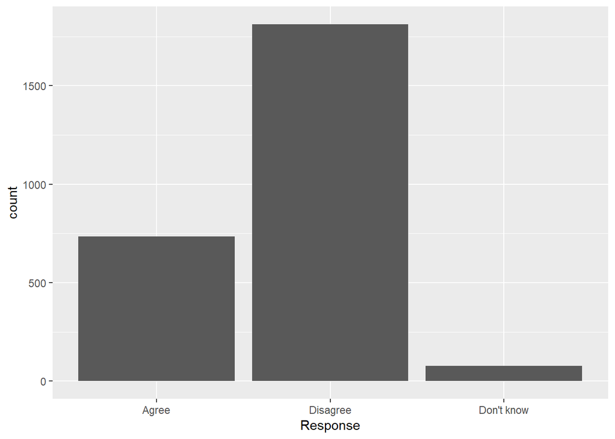

```r
gf_bar( ~ Response, data = OneTrueLove)
```

### Two Categorical Variables: Two-Way Tables

Often, it is useful to compute cross tables for two (or more) variables. We can again use `tally()()` for several ways to investigate a two-way table.

#### Table 2.3

```r
tally( ~ Response + Gender, data = OneTrueLove)
```

```
##             Gender
## Response     Female Male
##   Agree         363  372
##   Disagree     1005  807
##   Don't know     44   34
```

#### Table 2.4

```r
tally( ~ Response + Gender, margins = TRUE, data = OneTrueLove)
```

```
##             Gender
## Response     Female Male Total
##   Agree         363  372   735
##   Disagree     1005  807  1812
##   Don't know     44   34    78
##   Total        1412 1213  2625
```

#### Example 2.5

Similar to one categorical variable, we can use the `prop()()` function to find the proportion of two variables. The first line results in the proportion of females who agree and the proportion of males who agree. The second line shows the proportion who agree that are female and the proportion who disagree that are female. The third results in the proportion of all the survey responders that are female.

```r
prop(Response~Gender, data = OneTrueLove)
```

```
## prop_Agree.Female   prop_Agree.Male
##         0.2570822         0.3066777
```

```r
prop(Gender~Response, data = OneTrueLove)
```

```
##      prop_Female.Agree   prop_Female.Disagree prop_Female.Don't know
##              0.4938776              0.5546358              0.5641026
```

```r
prop( ~ Gender, data = OneTrueLove)
```

```
## prop_Female
##   0.5379048
```

```r
tally(Response ~ Gender, data = OneTrueLove)
```

```
##             Gender
## Response     Female Male
##   Agree         363  372
##   Disagree     1005  807
##   Don't know     44   34
```

```r
tally( ~ Response | Gender, data = OneTrueLove)
```

```
##             Gender
## Response     Female Male
##   Agree         363  372
##   Disagree     1005  807
##   Don't know     44   34
```

```r
tally(Gender ~ Response, data = OneTrueLove)
```

```
##         Response
## Gender   Agree Disagree Don't know
##   Female   363     1005         44
##   Male     372      807         34
```

```r
tally( ~ Gender | Response, data = OneTrueLove)
```

```
##         Response
## Gender   Agree Disagree Don't know
##   Female   363     1005         44
##   Male     372      807         34
```

```r
tally( ~ Gender, format = "percent", data = OneTrueLove)
```

```
## Gender
##   Female     Male
## 53.79048 46.20952
```

#### Example 2.6

```r
tally( ~ Gender + Award, margin = TRUE, data = StudentSurvey)
```

```
##        Award
## Gender  Academy Nobel Olympic Total
##   F          20    76      73   169
##   M          11    73     109   193
##   Total      31   149     182   362
```

Also, we can arrange the table differently by converting it to a data frame.

```r
as.data.frame(tally( ~ Gender + Award, data = StudentSurvey))
```

```
##   Gender   Award Freq
## 1      F Academy   20
## 2      M Academy   11
## 3      F   Nobel   76
## 4      M   Nobel   73
## 5      F Olympic   73
## 6      M Olympic  109
```

```r
prop( ~ Award, success = "Olympic", data = StudentSurvey)
```

```
## prop_Olympic
##    0.5027624
```

#### Example 2.7

To calculate the difference of certain statistics, we can use the `diff()()` function. Here we use it to find the difference in proportions, but it can be used for means, medians, and etc.

```r
diff(prop(Award~Gender, success = "Olympic", data = StudentSurvey))
```

```
## prop_Olympic.M
##      0.1328142
```

We will continue more with proportions in Chapter 3.

#### Figure 2.2

A way to look at multiple groups simultaneously is by using *comparative plots* such as a *segmented bar chart* or *side-by-side bar chart*. We often use the fill argument for this. fill is used when the assigned data is represented as an area, rather than a line or point. [^1]

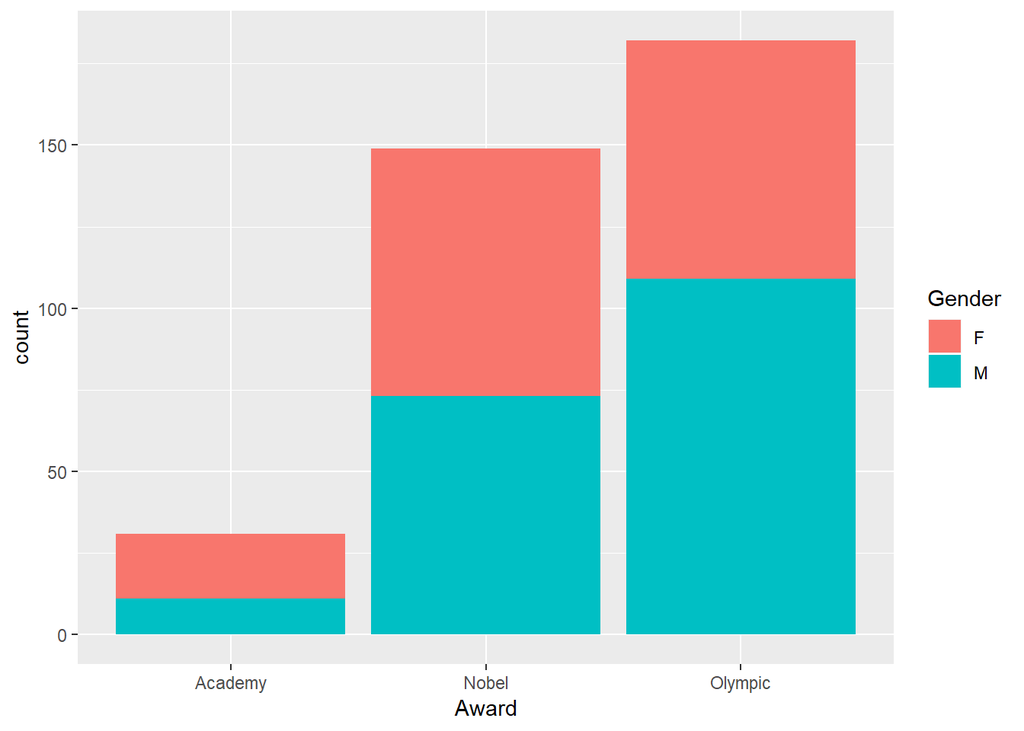

```r
gf_bar( ~ Award, fill = ~Gender, data = StudentSurvey)
```

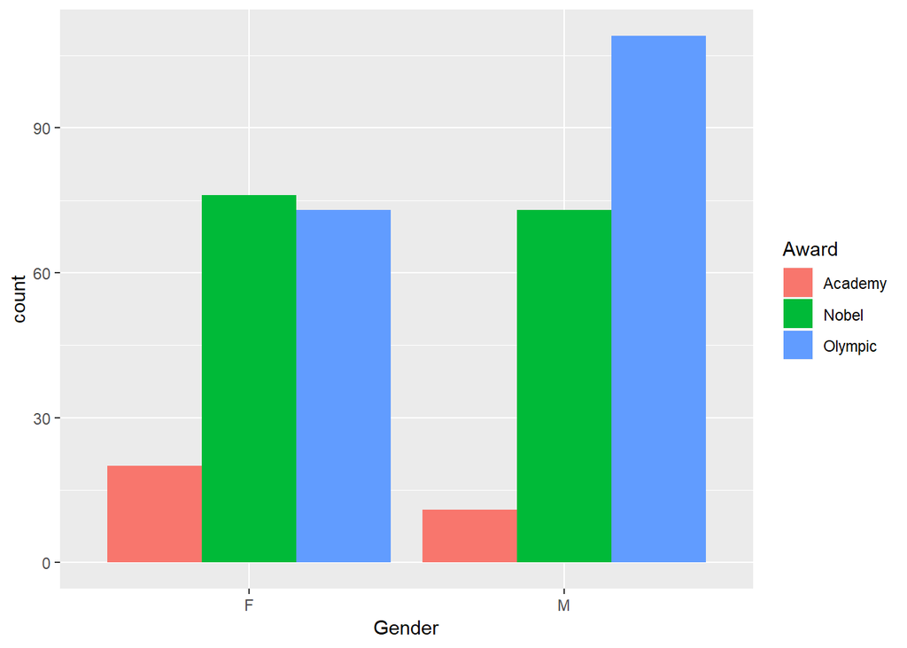

```r
gf_bar( ~ Gender, fill = ~Award, position = 'dodge', data = StudentSurvey)
```

## One Quantitative Variable: Shape and Center

The distribution of a variable answers two questions:

1. *What values* can the variable have?
2. *With what frequency* does each value occur?

Again, the frequency may be described in terms of counts, proportions (often called relative frequency), or densities (more on densities later).

A distribution may be described using a table (listing values and frequencies) or a graph (e.g., a histogram) or with words that describe general features of the distribution (e.g., symmetric, skewed).

```r
MammalLongevity
```

```
##          Animal Gestation Longevity
## 1        baboon       187        20
## 2    bear,black       219        18
## 3  bear,grizzly       225        25
## 4    bear,polar       240        20
## 5        beaver       122         5
## 6       buffalo       278        15
## 7         camel       406        12
## 8           cat        63        12
## 9    chimpanzee       231        20
## 10     chipmunk        31         6
## 11          cow       284        15
## 12         deer       201         8
## 13          dog        61        12
## 14       donkey       365        12
```

[output cut: 26 more lines]

Statisticians have devised a number of graphs to help us see distributions visually.  
The general syntax for making a graph of one variable in a data frame is

```r
plotname( ~ variable, data = dataName)
```

This should look familiar from the previous section.

#### Figure 2.6

Let’s make a *dot plot* of the variable Longevity in the MammalLongevity data set for a quick and simple look at the distribution. We use the syntax provided above with two additional arguments to make the figure look the way we want it to. The next few sections will explain a few of the different arguments available for plots in R

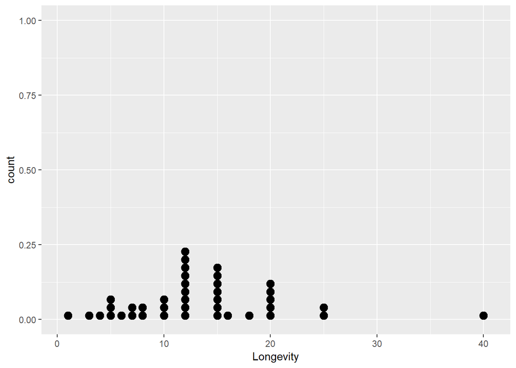

```r
gf_dotplot(~ Longevity, binwidth = 1, dotsize = .75, data = MammalLongevity)
```

#### Table 2.15

Although `tally()()` works with quantitative variables as well as categorical variables, this is only useful when there are not too many different values for the variable.

```r
tally( ~ Longevity, margin = TRUE, data = MammalLongevity)
```

```
## Longevity
##     1     3     4     5     6     7     8    10    12    15    16    18
##     1     1     1     3     1     2     2     3     9     7     1     1
##    20    25    40 Total
##     5     2     1    40
```

```r
binned.long <- cut(MammalLongevity$Longevity, breaks = c(0,5,10,15,20,25,30,35,40))
tally( ~ binned.long)      # no data frame given because it is not in a data frame
```

```
## binned.long
##   (0,5]  (5,10] (10,15] (15,20] (20,25] (25,30] (30,35] (35,40]
##       6       8      16       7       2       0       0       1
```

We won’t use this very often however, since seeing this information in a histogram is typically more useful.

#### Figure 2.7

We can control the (approximate) number of bins using the bins argument. The number of bins (and to a lesser extent the positions of the bins) can make a histogram look quite different.

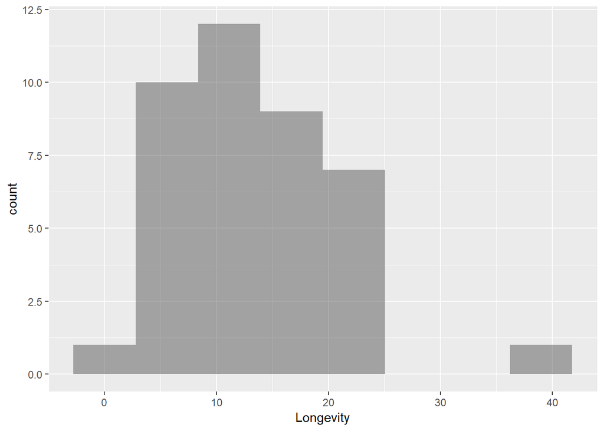

```r
gf_histogram( ~ Longevity, data = MammalLongevity, bins = 8)
```

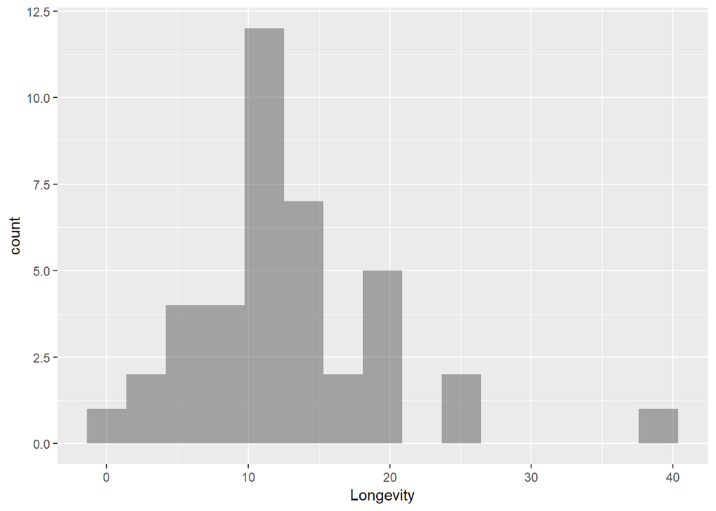

```r
gf_histogram( ~ Longevity, data = MammalLongevity, bins = 15)
```

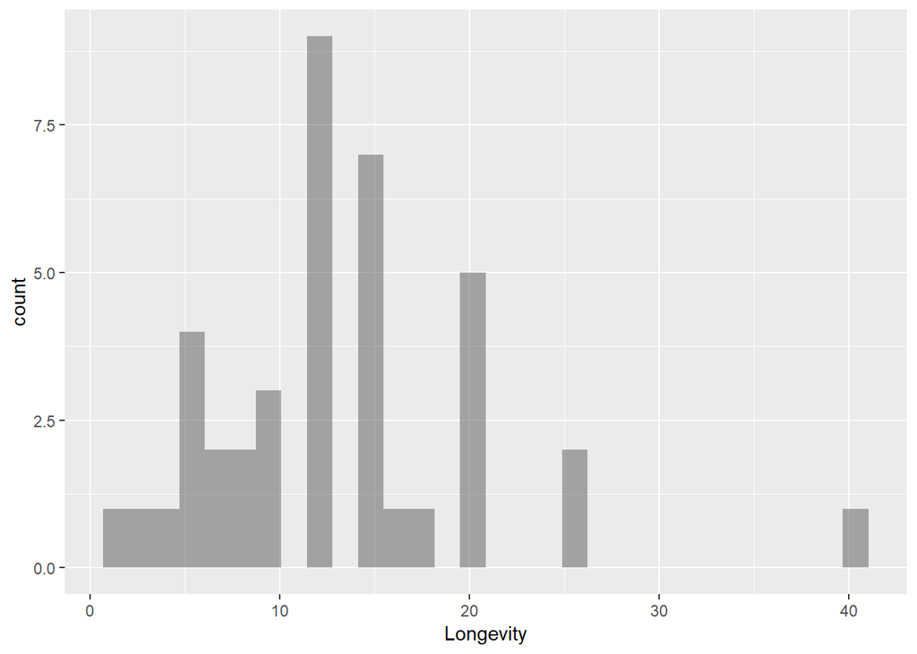

```r
gf_histogram( ~ Longevity, data = MammalLongevity, bins = 30)
```

We can also describe the bins in terms of width instead of in terms of the number of bins. This is especially nice for count or other integer data.

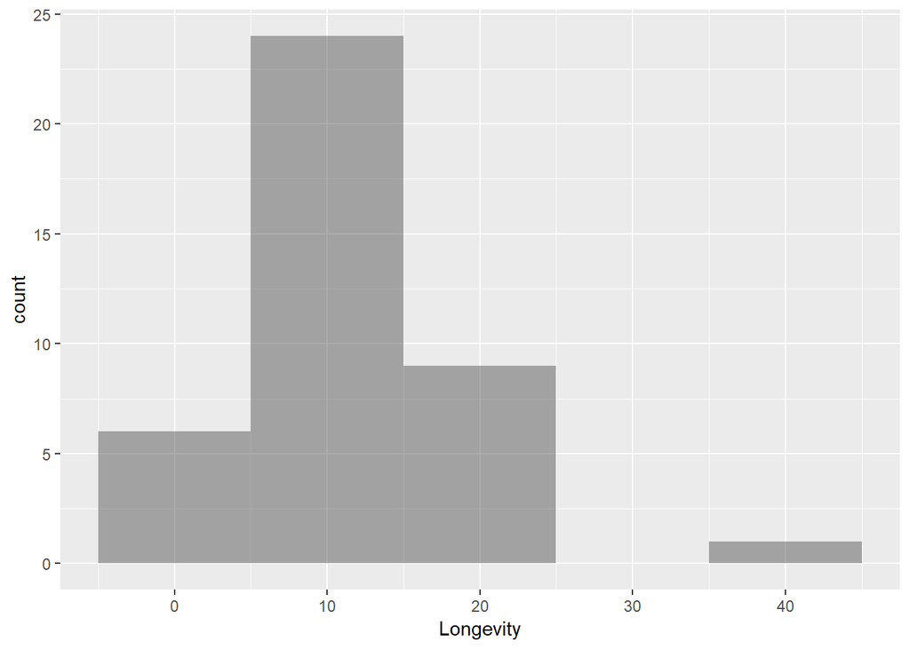

```r
gf_histogram( ~ Longevity, data = MammalLongevity, binwidth = 10)
```

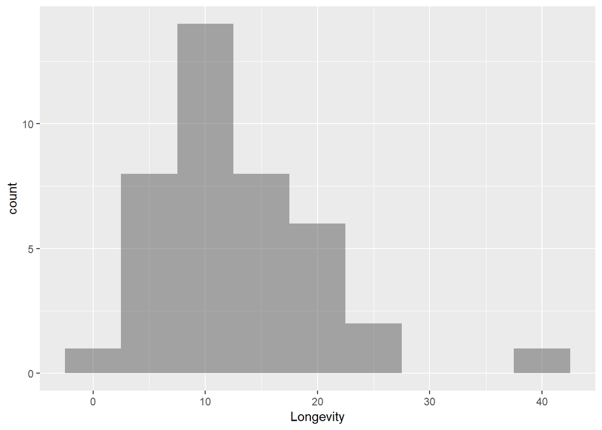

```r
gf_histogram( ~ Longevity, data = MammalLongevity, binwidth = 5)
```

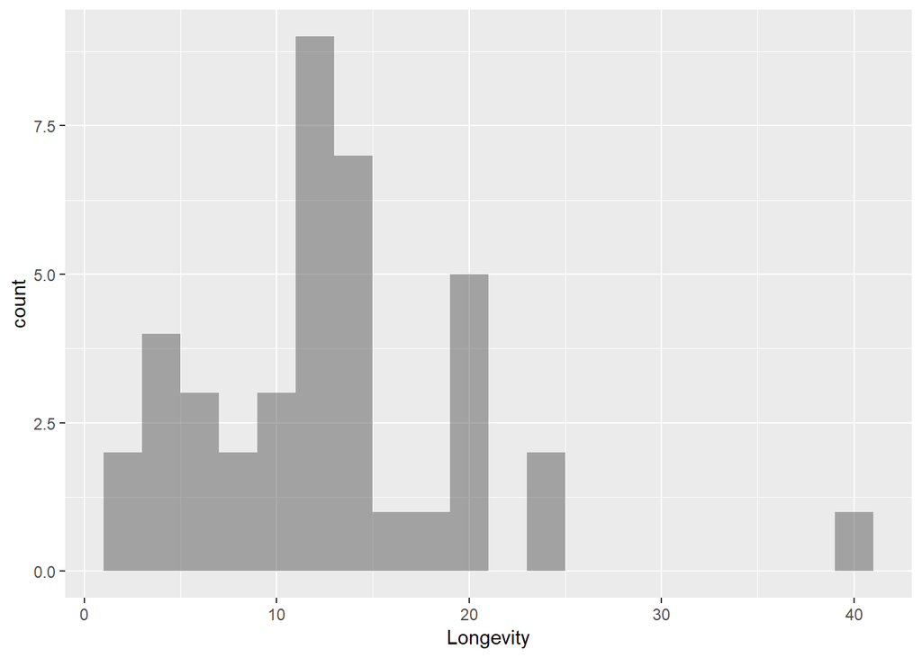

```r
gf_histogram( ~ Longevity, data = MammalLongevity, binwidth = 2)
```

The various options available for the `gf_histogram()()` function enable us to replicate Figure 2.8, some including closing, adding counts, labels, and limit to the y-axis (similar for x-axis). Using `gf_dhistogram()()` measures the y-axis by density rather than count. This is useful for determing relative amounts.

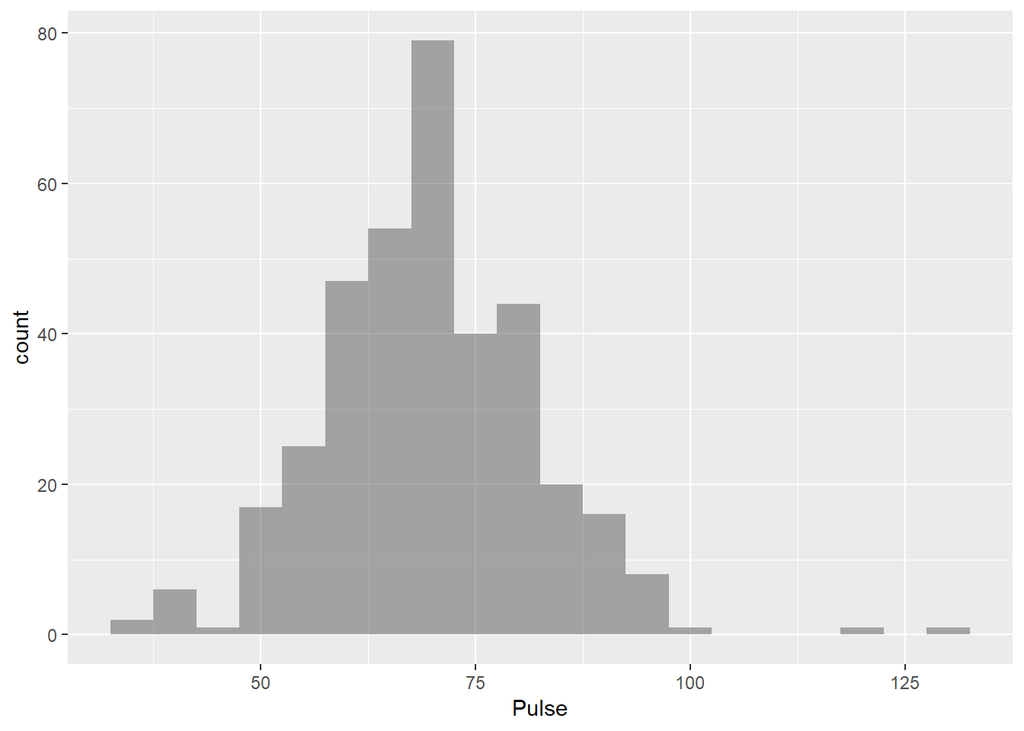

```r
gf_histogram( ~ Pulse, binwidth = 5, data = StudentSurvey)
```

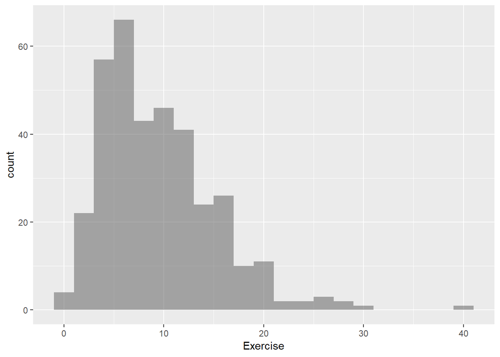

```r
gf_histogram( ~ Exercise, binwidth = 2, closed = 'left',
              data = StudentSurvey)
```

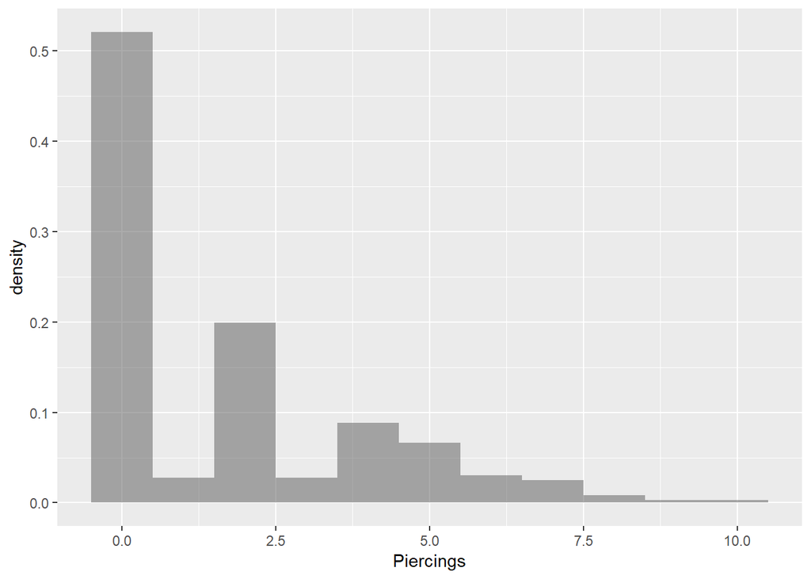

```r
gf_dhistogram( ~Piercings, binwidth = 1, data = StudentSurvey)
```

Sometimes a **frequency polygon** provides a more useful view. The only thing that changes is `gf_histogram()()` becomes `gf_freqpoly()()`.

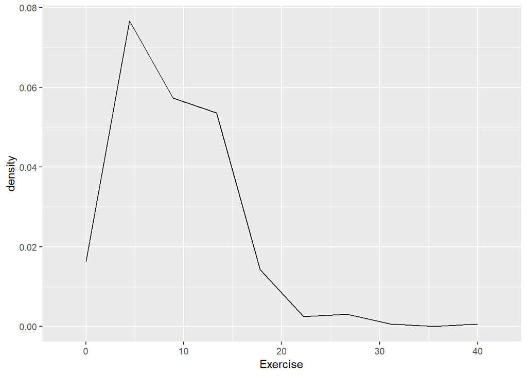

```r
gf_freqpoly(..density.. ~ Exercise, bins = 10, data = StudentSurvey)
```

What is a frequency polygon? The picture below shows how it is related to a histogram. The frequency polygon is just a dot-to-dot drawing through the centers of the tops of the bars of the histogram.

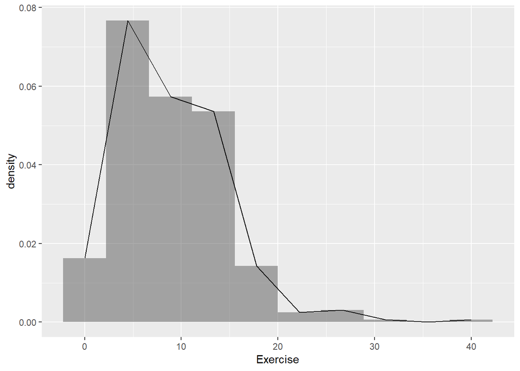

R also provides a “smooth” version called a density plot; just change the function name from `gf_histogram()()` to `gf_density()()`, also `gf_dens()()` is a modified version of `gf_density()` that isn’t shaded in and may be useful for layering plots.

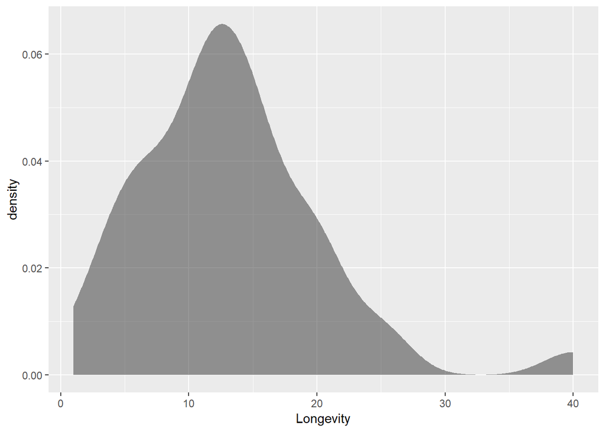

```r
gf_density( ~ Longevity, data = MammalLongevity)
```

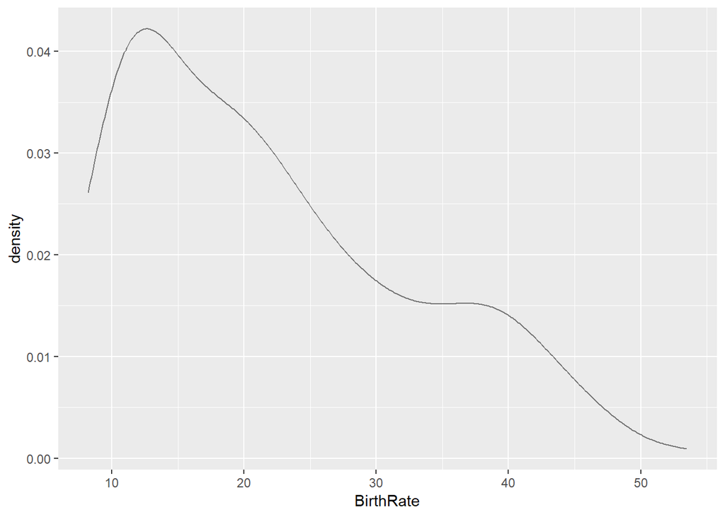

```r
gf_dens( ~ BirthRate, data = AllCountries )
```

If we make a histogram (or any of these other plots) of our data, we can describe the overall shape of the distribution. Keep in mind that the shape of a particular histogram may depend on the choice of bins. Choosing too many or too few bins can hide the true shape of the distribution. (When in doubt, make more than one histogram.)

Here are some words we use to describe shapes of distributions.

1. **symmetric** The left and right sides are mirror images of each other.
2. **skewed** The distribution stretches out farther in one direction than in the other.  
   (We say the distribution is skewed toward the long tail.)
3. **uniform** The heights of all the bars are (roughly) the same.  
   (So the data are equally likely to be anywhere within some range.)
4. **unimodal** There is one major “bump” where there is a lot of data.
5. **bimodal** There are two “bumps”.
6. **outlier** An observation that does not fit the overall pattern of the rest of the data.

### The Center of a Distribution

Recall that a statistic is a number computed from data. The **mean** and the **median** are key statistics which describe the center of a distribution. We can see through Example 2.11 that numerical summaries are computed using the same template as graphical summaries.

Note that the example asks about subsets of ICUAdmissions–specifically about 20-year-old and 55-year-old patients. In this case, we can manipulate the data (to name a new data set) with the subset command. Here are some examples.

```r
head(ICUAdmissions, 2)
```

```
##   ID Status Age Sex Race Service Cancer Renal Infection CPR Systolic
## 1  8      0  27   1    1       0      0     0         1   0      142
## 2 12      0  59   0    1       0      0     0         0   0      112
##   HeartRate Previous Type Fracture PO2 PH PCO2 Bicarbonate Creatinine
## 1        88        0    1        0   0  0    0           0          0
## 2        80        1    1        0   0  0    0           0          0
##   Consciousness status    sex  race service cancer renal infection cpr
## 1             1  Lived Female White Medical     No    No       Yes  No
## 2             1  Lived   Male White Medical     No    No        No  No
##   previous      type pO2low pO2 pHlow pH pCO2hi pCO2 bicarbonateLow
## 1       No Emergency     No  Hi    No Hi     No  Low             No
## 2      Yes Emergency     No  Hi    No Hi     No  Low             No
##   bicarbonate creatinineHi creatinine consciousness
## 1          Hi           No        Low     Conscious
## 2          Hi           No        Low     Conscious
```

```r
tally( ~ sex, data = ICUAdmissions)
```

```
## sex
## Female   Male
##     76    124
```

```r
ICUMales <- subset(ICUAdmissions, sex == "Male") # notice the double =
tally( ~ sex, data = ICUMales)
```

```
## sex
## Female   Male
##      0    124
```

[output not shown]

```r
ICUOld <- subset(ICUAdmissions, Age > 50)
```

The `subset()()` function can use any condition that evaluates to TRUE or FALSE for each row (case) in the data set.

```r
ICU20 <- subset(ICUAdmissions, Age == "20")
mean( ~ HeartRate, data = ICU20)
```

```
## [1] 82.2
```

```r
median( ~ HeartRate, data = ICU20)
```

```
## [1] 80
```

```r
ICU55 = subset(ICUAdmissions, Age == "55")
mean( ~ HeartRate, data = ICU55)
```

```
## [1] 108.5
```

```r
median( ~ HeartRate, data = ICU55)
```

```
## [1] 106
```

```r
head(FloridaLakes)
```

```
##   ID         Lake Alkalinity  pH Calcium Chlorophyll AvgMercury NumSamples
## 1  1    Alligator        5.9 6.1     3.0         0.7       1.23          5
## 2  2        Annie        3.5 5.1     1.9         3.2       1.33          7
## 3  3       Apopka      116.0 9.1    44.1       128.3       0.04          6
## 4  4 Blue Cypress       39.4 6.9    16.4         3.5       0.44         12
## 5  5        Brick        2.5 4.6     2.9         1.8       1.20         12
## 6  6       Bryant       19.6 7.3     4.5        44.1       0.27         14
##   MinMercury MaxMercury ThreeYrStdMercury AgeData
## 1       0.85       1.43              1.53       1
## 2       0.92       1.90              1.33       0
## 3       0.04       0.06              0.04       0
## 4       0.13       0.84              0.44       0
## 5       0.69       1.50              1.33       1
## 6       0.04       0.48              0.25       1
```

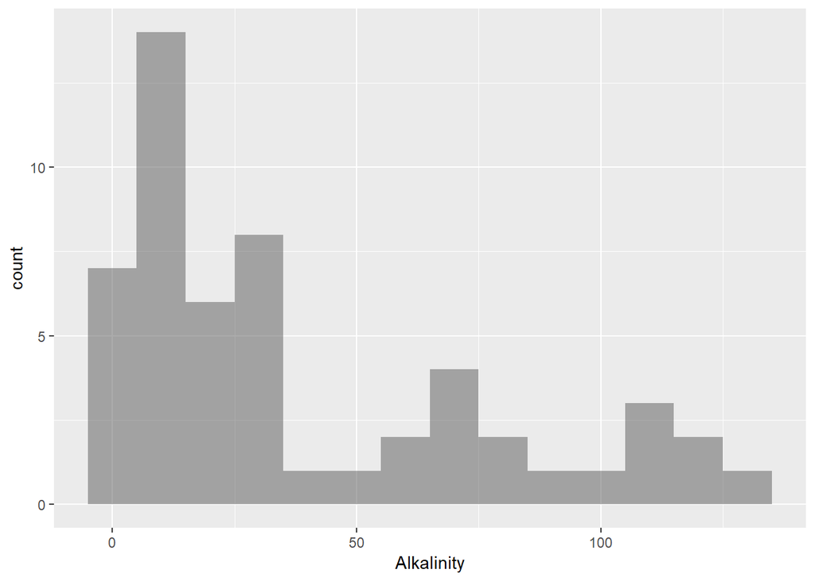

```r
gf_histogram( ~ Alkalinity, binwidth = 10, data = FloridaLakes)
```

```r
mean( ~ Alkalinity, data = FloridaLakes)
```

```
## [1] 37.53019
```

```r
median( ~ Alkalinity, data = FloridaLakes)
```

```
## [1] 19.6
```

## One Quantitative Variable: Measures of Spread

In the previous section, we investigated center summary statistics. In this section, we will cover some other important statistics.

```r
summary(April14Temps)
```

```
##       Year        DesMoines      SanFrancisco
##  Min.   :1995   Min.   :37.20   Min.   :48.70
##  1st Qu.:1999   1st Qu.:44.40   1st Qu.:51.30
##  Median :2002   Median :54.50   Median :54.00
##  Mean   :2002   Mean   :54.49   Mean   :54.01
##  3rd Qu.:2006   3rd Qu.:61.27   3rd Qu.:55.90
##  Max.   :2010   Max.   :74.90   Max.   :61.00
```

```r
favstats( ~ DesMoines, data = April14Temps) # some favorite statistics
```

```
##   min   Q1 median     Q3  max    mean      sd  n missing
##  37.2 44.4   54.5 61.275 74.9 54.4875 11.7303 16       0
```

```r
favstats( ~ SanFrancisco, data = April14Temps)
```

```
##   min   Q1 median   Q3 max    mean       sd  n missing
##  48.7 51.3     54 55.9  61 54.0125 3.376956 16       0
```

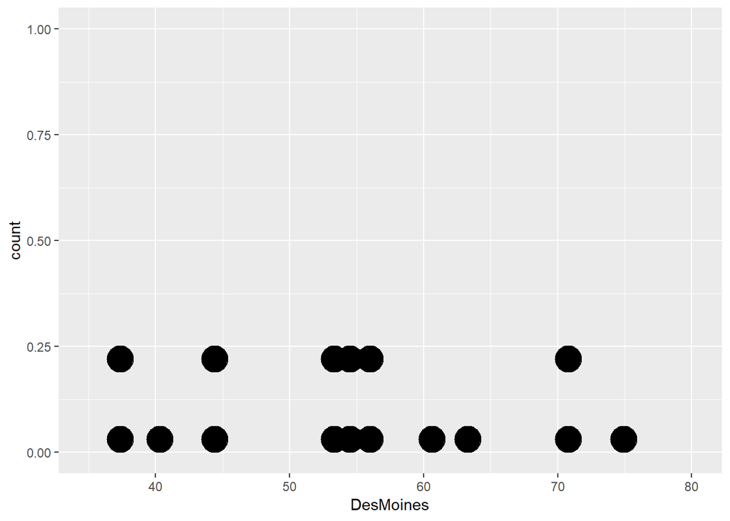

```r
gf_dotplot( ~ DesMoines, binwidth = 1, dotsize = 2, stackratio = 3,
            data = April14Temps) %>% gf_lims(x = c(35, 80))
```

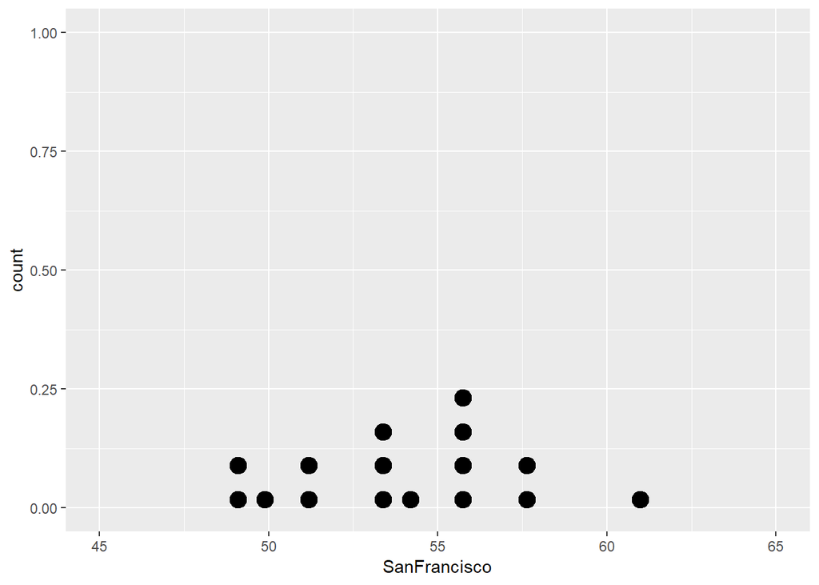

```r
gf_dotplot( ~ SanFrancisco, binwidth = 1, dotsize = .5, stackratio = 2,
            data = April14Temps) %>% gf_lims(x = c(45, 65))
```

```r
sd( ~ DesMoines, data = April14Temps)
```

```
## [1] 11.7303
```

```r
sd( ~ SanFrancisco, data = April14Temps)
```

```
## [1] 3.376956
```

```r
var( ~ DesMoines, data = April14Temps)        # variance = sd^2
```

```
## [1] 137.5998
```

To see that the distribution is indeed symmetric and approximately bell-shaped, you can chain the function `gf_dens()()`. It can be helpful to set alpha (the transparency argument) lower than 1 to make the plot easier to read.

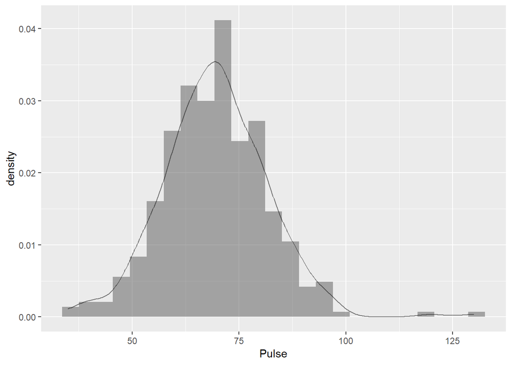

```r
gf_dhistogram( ~ Pulse, data = StudentSurvey, alpha = .5) %>% gf_dens( ~ Pulse)
```

```r
mean <- mean( ~ Pulse, data = StudentSurvey); mean
```

```
## [1] 69.57459
```

```r
sd <- sd( ~ Pulse, data = StudentSurvey); sd
```

```
## [1] 12.20514
```

```r
mean - 2*sd
```

```
## [1] 45.16431
```

```r
mean + 2*sd
```

```
## [1] 93.98486
```

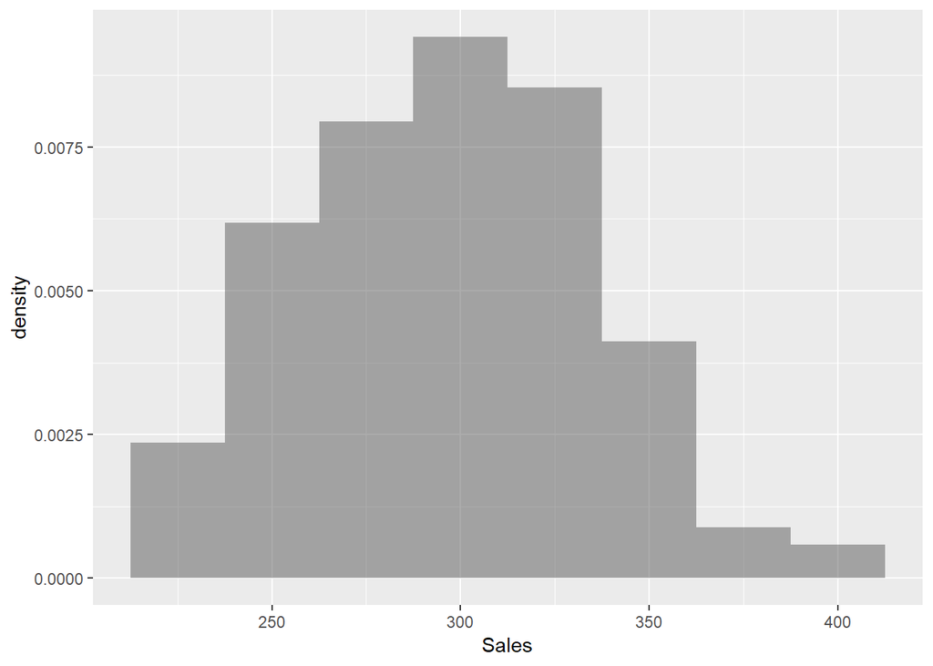

```r
gf_dhistogram( ~ Sales, binwidth = 25, data = RetailSales)
```

```r
mean <- mean( ~ Sales, data = RetailSales); mean
```

```
## [1] 296.4382
```

```r
sd <- sd( ~ Sales, data = RetailSales); sd
```

```
## [1] 37.97074
```

```r
mean - 2*sd
```

```
## [1] 220.4968
```

```r
mean + 2*sd
```

```
## [1] 372.3797
```

Z-scores can be computed as follows:

```r
( 204 - mean( ~ Systolic, data = ICUAdmissions) ) / sd( ~ Systolic, data = ICUAdmissions)
```

```
## [1] 2.176493
```

```r
( 52 - mean( ~ HeartRate, data = ICUAdmissions) ) / sd( ~ HeartRate, data = ICUAdmissions)
```

```
## [1] -1.749
```

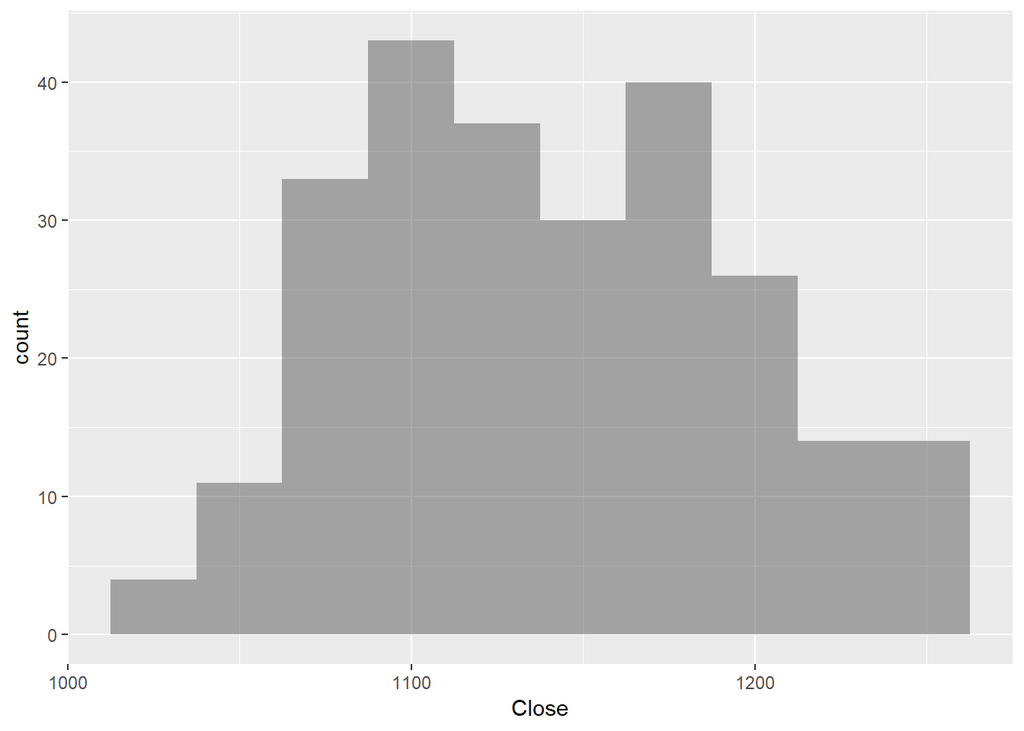

```r
gf_histogram( ~ Close, binwidth = 25, data = SandP500)
```

The text uses a histogram to estimate the **percentile** of the daily closing price for the S&P 500 but we can also find the exact percentiles using the `quantile()()` function.

```r
quantile(SandP500$Close, probs = seq(0, 1, 0.25))
```

```
##       0%      25%      50%      75%     100%
## 1022.580 1094.802 1136.985 1183.372 1259.780
```

```r
quantile(SandP500$Close, probs = seq(0, 1, 0.90))
```

```
##       0%      90%
## 1022.580 1216.906
```

We have already covered many different functions which results in the **five number summary** but `fivenum()()` is most direct way to obtain in the five number summary.

```r
fivenum( ~ Exercise, data = StudentSurvey)
```

[output not shown]

```r
fivenum( ~ Longevity, data = MammalLongevity)
```

```
## [1]  1.0  8.0 12.0 15.5 40.0
```

```r
min( ~ Longevity, data = MammalLongevity)
```

```
## [1] 1
```

```r
max( ~ Longevity, data = MammalLongevity)
```

```
## [1] 40
```

```r
range( ~ Longevity, data = MammalLongevity)  # subtract to get the numerical range value
```

```
## [1]  1 40
```

```r
iqr( ~ Longevity, data = MammalLongevity)   # interquartile range
```

```
## [1] 7.25
```

Note the difference in the quartile and IQR from the textbook. This results because there are several different methods to determine the quartile.

```r
fivenum( ~ DesMoines, data = April14Temps)
```

```
## [1] 37.20 44.40 54.50 61.95 74.90
```

```r
fivenum( ~ SanFrancisco, data = April14Temps)
```

```
## [1] 48.7 51.2 54.0 56.0 61.0
```

```r
range( ~ DesMoines, data = April14Temps)
```

```
## [1] 37.2 74.9
```

```r
diff(range( ~ DesMoines, data = April14Temps))
```

```
## [1] 37.7
```

```r
range( ~ SanFrancisco, data = April14Temps)
```

```
## [1] 48.7 61.0
```

```r
diff(range( ~ SanFrancisco, data = April14Temps))
```

```
## [1] 12.3
```

```r
iqr( ~ DesMoines, data = April14Temps)
```

```
## [1] 16.875
```

```r
iqr( ~ SanFrancisco, data = April14Temps)
```

```
## [1] 4.6
```

## Outliers, Boxplots, and Quantitative/Categorical Relationships

#### Example 2.25

```r
fivenum( ~ Longevity, data = MammalLongevity)
```

```
## [1]  1.0  8.0 12.0 15.5 40.0
```

```r
iqr( ~ Longevity, data = MammalLongevity)
```

```
## [1] 7.25
```

```r
8.0-1.5*7.25
```

```
## [1] -2.875
```

```r
15.5+1.5*7.25
```

```
## [1] 26.375
```

```r
subset(MammalLongevity, Longevity>26.375)
```

```
##      Animal Gestation Longevity
## 15 elephant       645        40
```

There is no function in R that directly results in outliers because practically, there is no one specific formula for such a determination. However, a boxplot will indirectly reveal outliers.

A way to visualize the five number summary and outliers for a variable is to create a boxplot.

```r
favstats( ~ Longevity, data = MammalLongevity)
```

```
##  min Q1 median    Q3 max  mean       sd  n missing
##    1  8     12 15.25  40 13.15 7.244981 40       0
```

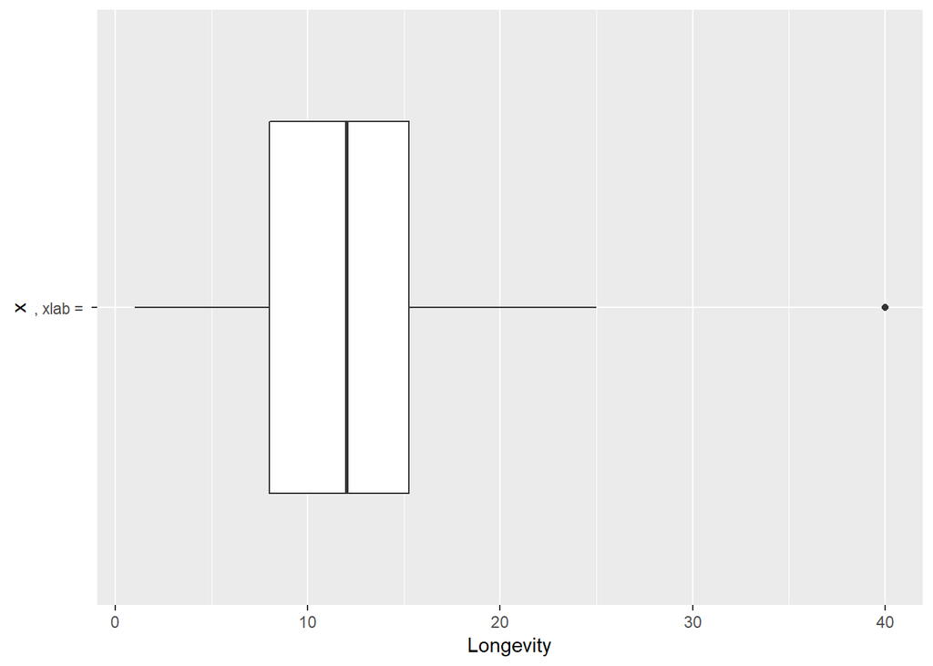

```r
gf_boxplot(Longevity ~ ", xlab = ", data = MammalLongevity) %>%
  gf_refine(coord_flip())
```

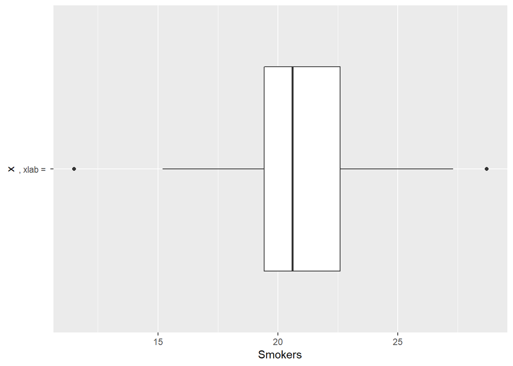

```r
gf_boxplot(Smokers ~ ", xlab = ", data = USStates) %>%
  gf_refine(coord_flip())
```

We can similarity investigate the *Smokers* variable in USStates.

```r
fivenum( ~ Smokers, data = USStates)
```

```
## [1] 11.5 19.3 20.6 22.6 28.7
```

The boxplot reveals two outliers. To identify them, we can again use `subset()()` for smokers greater or less than the *whiskers* of the boxplot.

```r
subset(USStates, Smokers<15)
```

```
##    State HouseholdIncome    IQ McCainVote Region ObamaMcCain Population
## 44  Utah           55619 101.1      0.629      W           M   2.420708
##    EighthGradeMath HighSchool   GSP FiveVegetables Smokers
## 44          279.16         91 36758           22.1    11.5
##    PhysicalActivity Obese College NonWhite HeavyDrinkers Pres2008
## 44             83.1  21.2      31     12.1           2.9   McCain
```

```r
subset(USStates, Smokers>28)
```

```
##       State HouseholdIncome   IQ McCainVote Region ObamaMcCain Population
## 17 Kentucky           38694 99.4      0.575     MW           M   4.141835
##    EighthGradeMath HighSchool   GSP FiveVegetables Smokers
## 17          273.98       81.8 33666           16.8    28.7
##    PhysicalActivity Obese College NonWhite HeavyDrinkers Pres2008
## 17             70.1  28.6    22.6      9.4           2.7   McCain
```

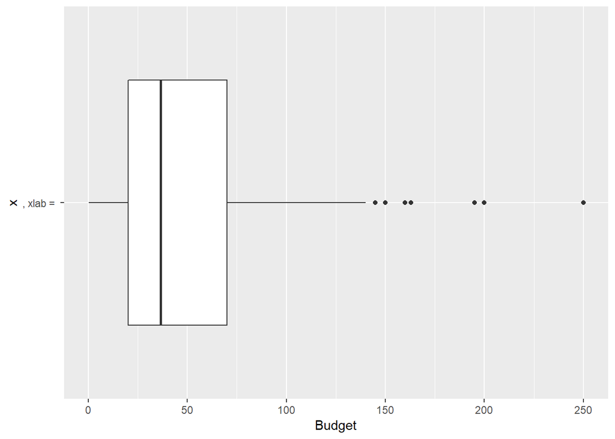

```r
gf_boxplot(Budget ~ ", xlab = ", data = HollywoodMovies2011) %>%
  gf_refine(coord_flip())
```

```r
subset(HollywoodMovies2011, Budget>225)
```

```
##                                           Movie LeadStudio RottenTomatoes
## 30 Pirates of the Caribbean:\nOn Stranger Tides     Disney             34
##    AudienceScore Story  Genre TheatersOpenWeek BOAverageOpenWeek
## 30            61 Quest Action             4155             21697
##    DomesticGross ForeignGross WorldGross Budget Profitability
## 30        241.07        802.8   1043.871    250      4.175484
##    OpeningWeekend
## 30          90.15
```

```r
head(HollywoodMovies2011)
```

```
##                                         Movie       LeadStudio
## 1                                   Insidious             Sony
## 2                       Paranormal Activity 3      Independent
## 3                                 Bad Teacher      Independent
## 4 Harry Potter and the Deathly Hallows Part 2      Warner Bros
## 5                                 Bridesmaids Relativity Media
## 6                           Midnight in Paris             Sony
##   RottenTomatoes AudienceScore         Story   Genre TheatersOpenWeek
## 1             67            65 Monster Force  Horror             2408
## 2             68            58 Monster Force  Horror             3321
## 3             44            38        Comedy  Comedy             3049
## 4             96            92       Rivalry Fantasy             4375
## 5             90            77       Rivalry  Comedy             2918
## 6             93            84          Love Romance              944
##   BOAverageOpenWeek DomesticGross ForeignGross WorldGross Budget
## 1              5511         54.01        43.00     97.009    1.5
## 2             15829        103.66        98.24    201.897    5.0
## 3             10365        100.29       115.90    216.196   20.0
## 4             38672        381.01       947.10   1328.111  125.0
## 5              8995        169.11       119.28    288.382   32.5
## 6              6177         56.18        83.00    139.177   17.0
##   Profitability OpeningWeekend
## 1     64.672667          13.27
## 2     40.379400          52.57
## 3     10.809800          31.60
## 4     10.624888         169.19
## 5      8.873292          26.25
## 6      8.186882           5.83
```

The formula for a **`lattice`** plot can be extended to create multiple panels (sometimes called **facets**) based on a “condition”, often given by another variable. This is another way to look at multiple groups simultaneously. The general syntax for this becomes

```r
plotname( ~ variable | condition, data = dataName )
```

Depending on the type of plot, you will want to use conditioning.

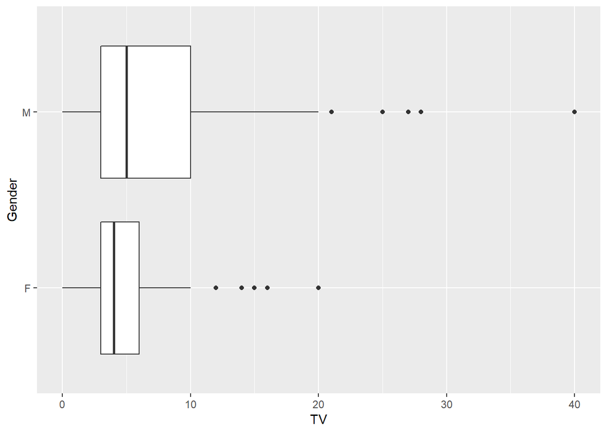

```r
gf_boxplot(TV ~ Gender, data = StudentSurvey) %>%
  gf_refine(coord_flip())
```

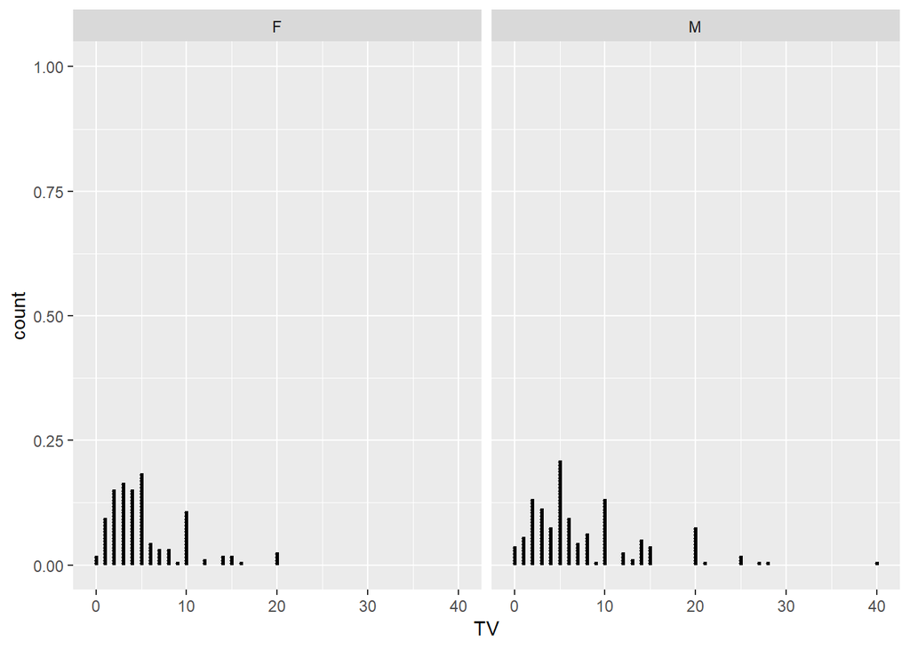

```r
gf_dotplot( ~ TV|Gender, binwidth = 1, dotsize = .35, data = StudentSurvey)
```

We can do the same thing for bar graphs.

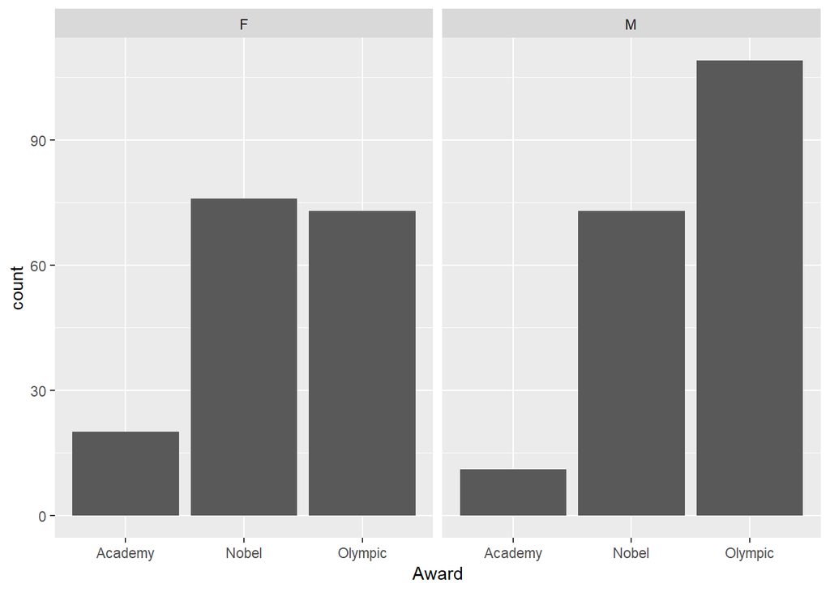

```r
gf_bar( ~ Award | Gender, data = StudentSurvey)
```

This graph should be familiar as we have plotted these variables together previously. Here we used different panels, but before, in 2.1, we had used grouping. Note that we can combine grouping and conditioning in the same plot.

```r
favstats( ~ TV | Gender, data = StudentSurvey)
diffmean( ~ TV | Gender, data = StudentSurvey)
```

[output not shown]

## Two Quantitative Variables: Scatterplot and Correlation

#### Example 2.32

```r
ElectionMargin
```

```
##    Year  Candidate Approval Margin Result
## 1  1940  Roosevelt       62   10.0    Won
## 2  1948     Truman       50    4.5    Won
## 3  1956 Eisenhower       70   15.4    Won
## 4  1964    Johnson       67   22.6    Won
## 5  1972      Nixon       57   23.2    Won
## 6  1976       Ford       48   -2.1   Lost
## 7  1980     Carter       31   -9.7   Lost
## 8  1984     Reagan       57   18.2    Won
## 9  1992 G.H.W.Bush       39   -5.5   Lost
## 10 1996    Clinton       55    8.5    Won
## 11 2004   G.W.Bush       49    2.4    Won
```

The most common way to look at two quantitative variables is with a scatterplot. The **`ggformula`** function for this is `gf_point()()`, and the basic syntax is

```r
gf_point(yvar ~ xvar, data = dataName)
```

Notice that now we have something on both sides of the ~{} since we need to tell about two variables.

#### Example 2.33

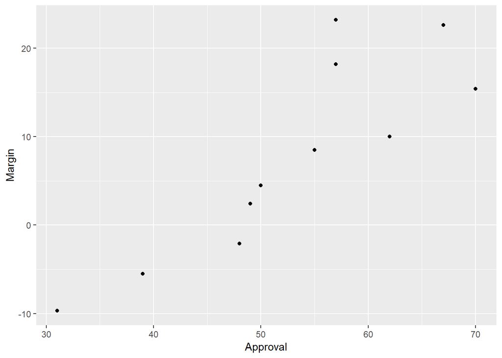

```r
gf_point(Margin ~ Approval, data = ElectionMargin)
```

#### Figure 2.49

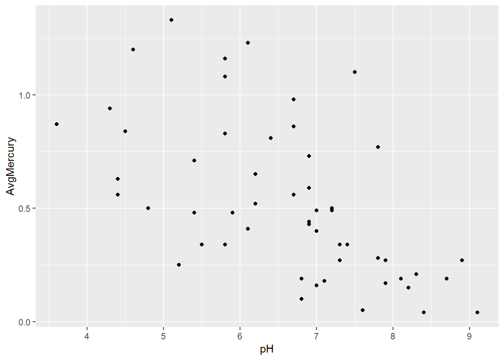

```r
gf_point(AvgMercury ~ pH, data = FloridaLakes)
```

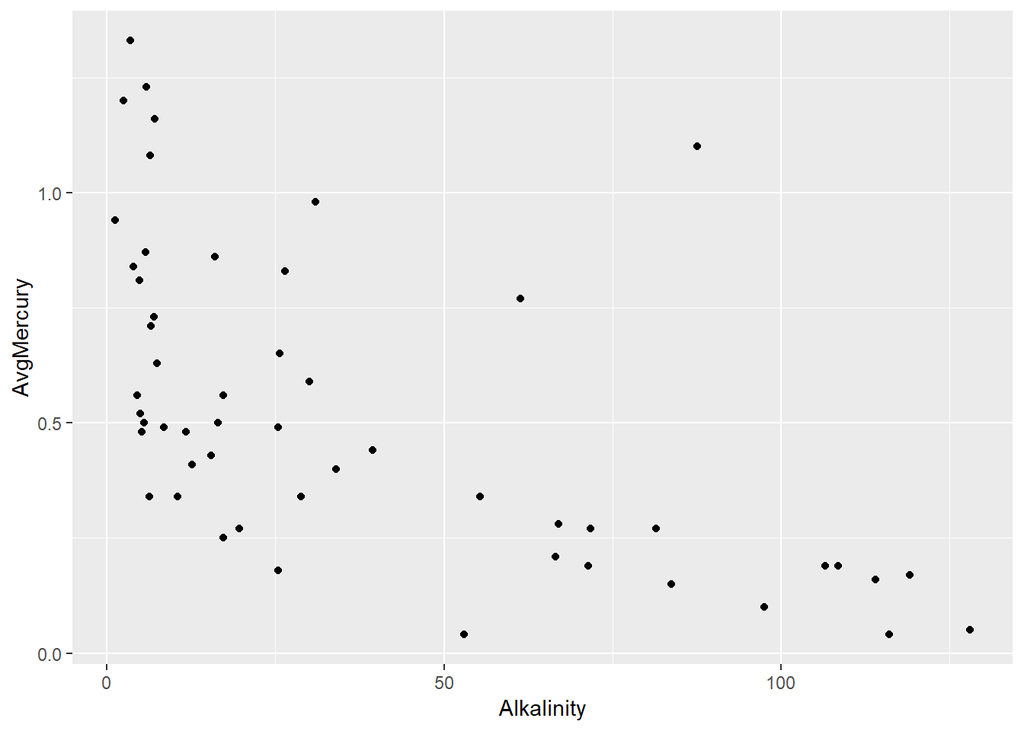

```r
gf_point(AvgMercury ~ Alkalinity, data = FloridaLakes)
```

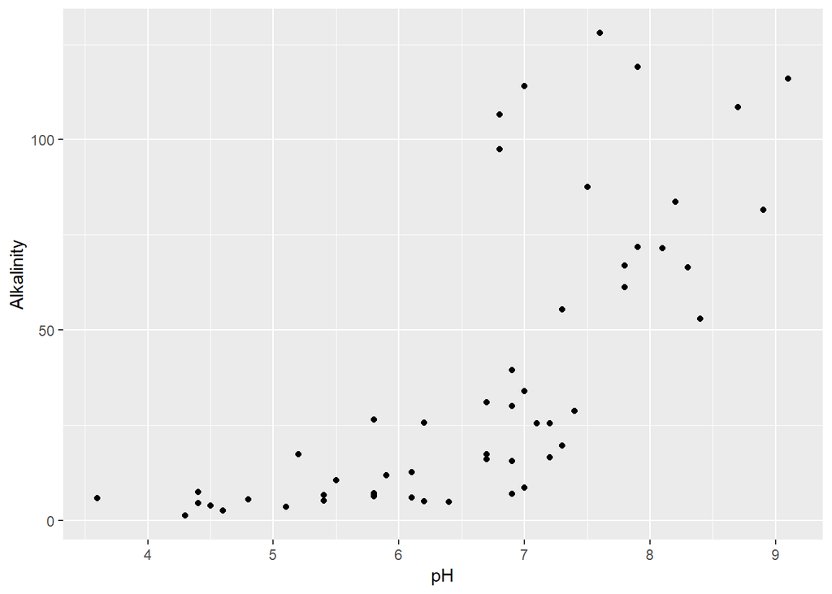

```r
gf_point(Alkalinity ~ pH, data = FloridaLakes)
```

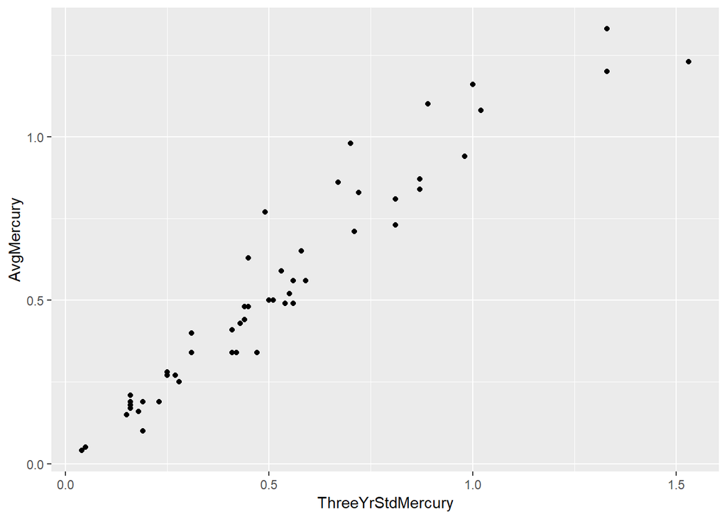

```r
gf_point(AvgMercury ~ ThreeYrStdMercury, data = FloridaLakes)
```

### Summarizing a Relationship between Two Quantitative Variables: Correlation

Another key numerical statistic is the **correlation**–the correlation is a measure of the strength and direction of the relationship between two quantitative variables.

```r
cor(Margin ~ Approval, data = ElectionMargin)
```

```
## [1] 0.8629926
```

```r
cor(AvgMercury ~ pH, data = FloridaLakes)
```

```
## [1] -0.5754001
```

```r
cor(AvgMercury ~ Alkalinity, data = FloridaLakes)
```

```
## [1] -0.5938967
```

```r
cor(Alkalinity ~ pH, data = FloridaLakes)
```

```
## [1] 0.7191657
```

```r
cor(AvgMercury ~ ThreeYrStdMercury, data = FloridaLakes)
```

```
## [1] 0.9592148
```

```r
CricketChirps
```

```
##   Temperature Chirps
## 1        54.5     81
## 2        59.5     97
## 3        63.5    103
## 4        67.5    123
## 5        72.0    150
## 6        78.5    182
## 7        83.0    195
```

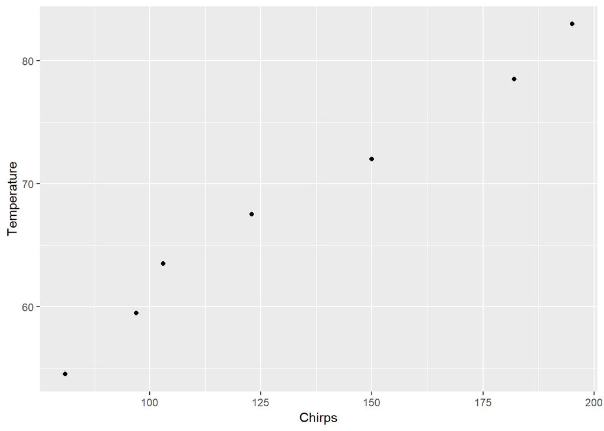

```r
gf_point(Temperature ~ Chirps, data = CricketChirps)
```

```r
cor(Temperature ~ Chirps, data = CricketChirps)
```

```
## [1] 0.9906249
```

Further, using the `subset()()` function again, we can investigate the correlation between variables with some restrictions.

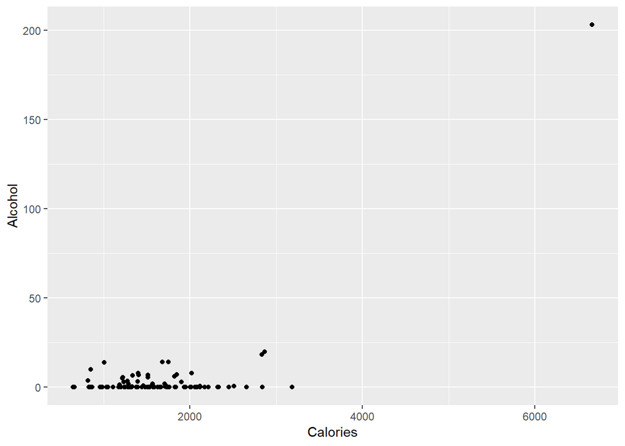

```r
gf_point(Alcohol ~ Calories, data = subset(NutritionStudy, Age>59))
```

```r
cor(Alcohol ~ Calories, data = subset(NutritionStudy, Age>59))
```

```
## [1] 0.7199945
```

And now we omit the outlier

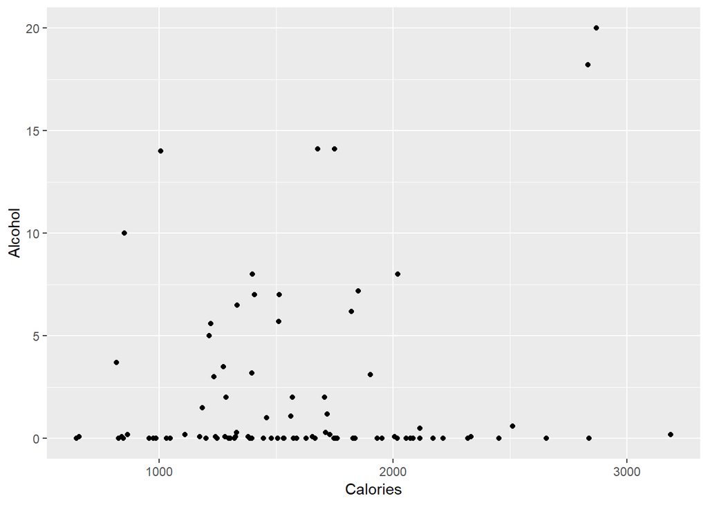

```r
NutritionStudy60 = subset(NutritionStudy, Age>59)
gf_point(Alcohol ~ Calories, data = subset(NutritionStudy60, Alcohol<25))
```

```r
cor(Alcohol ~ Calories, data = subset(NutritionStudy60, Alcohol<25))
```

```
## [1] 0.1449633
```

## Two Quantitative Variables: Linear Regression

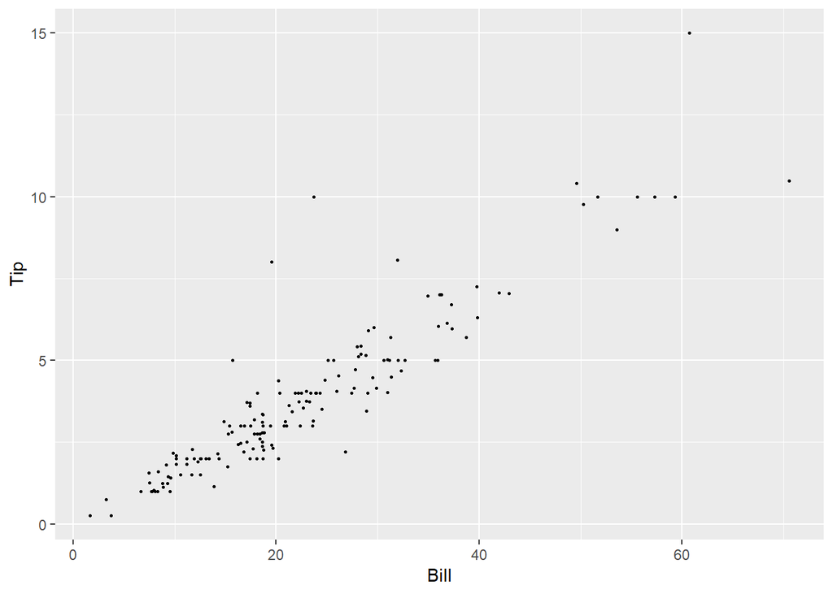

```r
gf_point(Tip ~ Bill, size = .5, data = RestaurantTips)
```

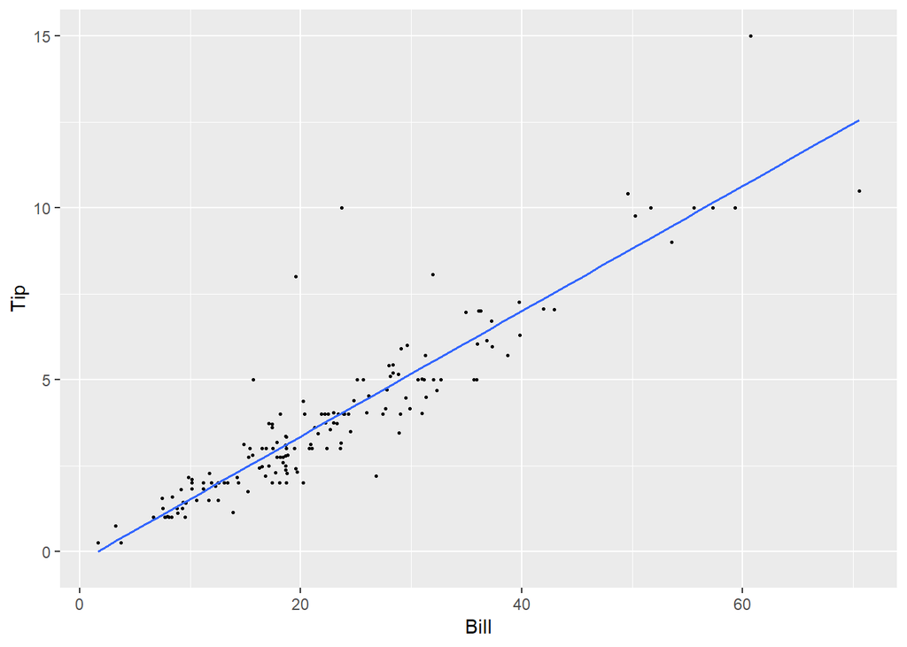

```r
gf_point(Tip ~ Bill, cex = 0.5, data = RestaurantTips) %>% gf_lm(Tip ~ Bill, data = RestaurantTips)
```

```r
cor(Tip ~ Bill, data = RestaurantTips)
```

```
## [1] 0.9150592
```

The equation for the regression line, or the *prediction equation* is
$$\widehat{\mbox{Response}} = a + b \cdot \mbox{Explanatory}$$

So now, we need to find the values for a, the intercept, and b, the slope using the function to fit linear models.

```r
lm(Tip ~ Bill, data = RestaurantTips)
```

```
##
## Call:
## lm(formula = Tip ~ Bill, data = RestaurantTips)
##
## Coefficients:
## (Intercept)         Bill
##     -0.2923       0.1822
```

```r
coef(lm(Tip ~ Bill, data = RestaurantTips))  # just show me the coefficients
```

```
## (Intercept)        Bill
##  -0.2922675   0.1822147
```

With this equation, one can predict the tip for different bill amounts.

```r
Tip.Fun <- makeFun(lm(Tip ~ Bill, data = RestaurantTips)) # make a function of the linear model
Tip.Fun(Bill = 59.33) # predicted tip when bill is $59.33
```

```
##        1
## 10.51853
```

```r
Tip.Fun(Bill = 9.52)
```

```
##        1
## 1.442417
```

```r
Tip.Fun(Bill = 23.70)
```

```
##        1
## 4.026222
```

An important aspect of the linear regression is the difference between the prediction and actual observation. This is called the **residual**, defined

$$\mbox{residual} = \mbox{observed response} - \mbox{predicted response}$$

```r
Resid.a <- 10.00 - 10.51 # predicted tip from Example 2.41
Resid.a
```

```
## [1] -0.51
```

```r
Resid.b <- 1.00 - 1.44
Resid.b
```

```
## [1] -0.44
```

```r
Resid.c <- 10.00 - 4.02
Resid.c
```

```
## [1] 5.98
```

```r
Elect.mod <- lm(Margin~Approval, data = ElectionMargin)
resid(lm(Margin~Approval, data = ElectionMargin))
```

```
##          1          2          3          4          5          6
## -5.3228564 -0.7958766 -6.6075096  3.0992354 12.0550519 -5.7247133
##          7          8          9         10         11
##  0.8801748  7.0550519 -1.6044784 -0.9737848 -2.0602949
```

```r
lm(AvgMercury ~ pH, data = FloridaLakes)
```

```
##
## Call:
## lm(formula = AvgMercury ~ pH, data = FloridaLakes)
##
## Coefficients:
## (Intercept)           pH
##      1.5309      -0.1523
```

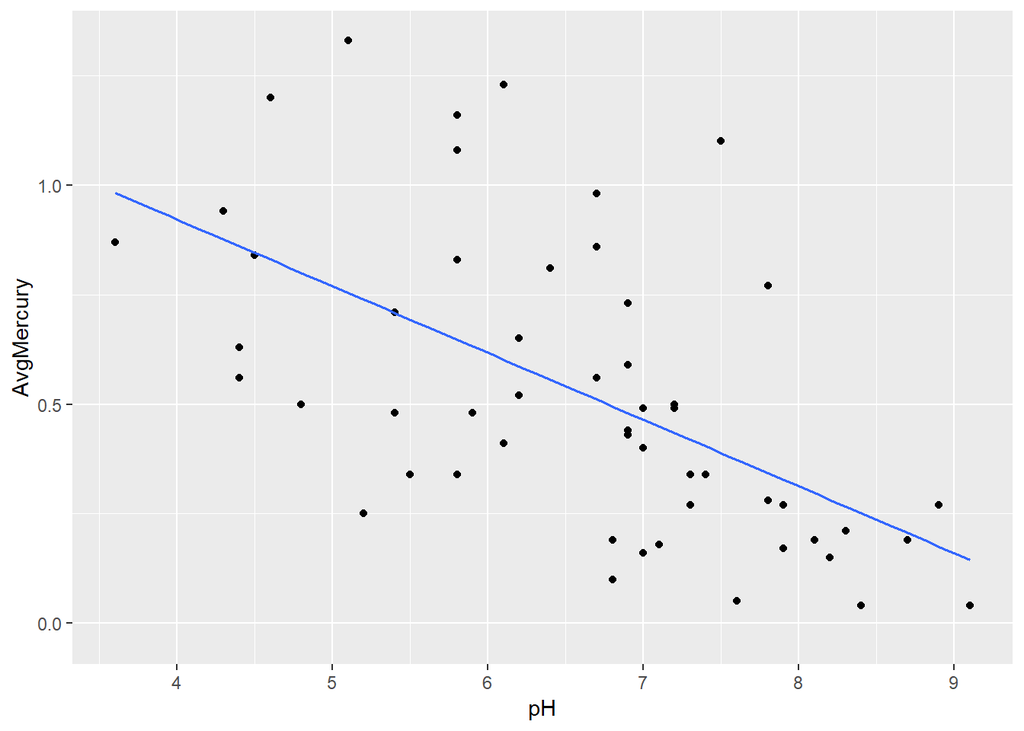

```r
gf_point(AvgMercury ~ pH, data = FloridaLakes) %>% gf_lm(AvgMercury ~ pH, data = FloridaLakes)
```

```r
Mer.Fun <- makeFun(lm(AvgMercury ~ pH, data = FloridaLakes))
Mer.Fun(pH = 7.5) # predicted mercury level at 7.5 pH
```

```
##         1
## 0.3886622
```

```r
Resid <- 1.10 - 0.388 # residual at 7.5 pH
Resid
```

```
## [1] 0.712
```

```r
Cal.Fun <- makeFun(lm(Calcium ~ pH, data = FloridaLakes))
Cal.Fun
```

```
## function (pH, ..., transformation = function (x)
## x)
## return(transformation(predict(model, newdata = data.frame(pH = pH),
##     ...)))
## <environment: 0x000000001c6b60e0>
## attr(,"coefficients")
## (Intercept)          pH
##   -51.40157    11.16800
```

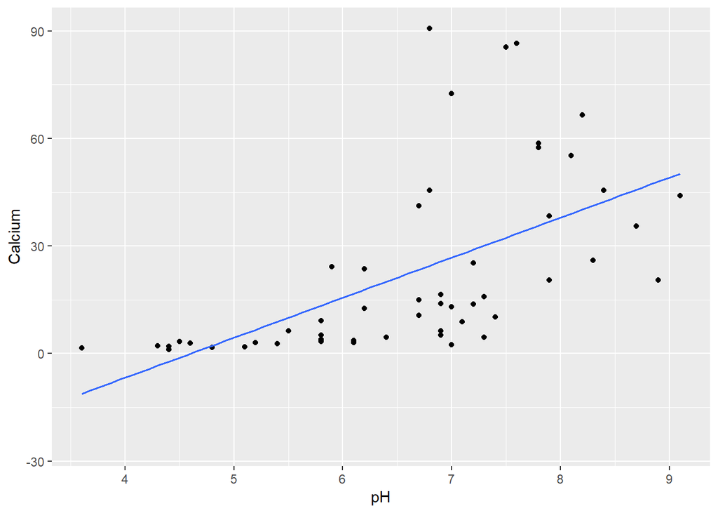

```r
gf_point(Calcium ~ pH, data = FloridaLakes) %>% gf_lm(Calcium ~ pH, data = FloridaLakes)
```

## Graphical Summaries – Important Ideas

The goal of a statistical plot is to help us see

1. potential patterns in the data, and
2. deviations from those patterns.

Graphical summaries can help us see the *distribution* of a variable or the *relationships* between two (or more) variables. The type of plot used will depend on the kinds of variables involved. You can use `demo()()` to see how to get R to make the plots in this section.

When we do statistical analysis, we will see that the analysis we use will also depend on the kinds of variables involved, so this is an important idea.

The **`ggformula`** graphics plots make it particularly easy to generate plots that divide the data into groups and either produce a panel for each group (using |!) or display each group in a different way (different colors or symbols, using the fill or colour arguments). These plots can reveal the possible influence of additional variables – sometimes called covariates.

Many plots are based on the key idea that our eyes are good at comparing areas. Plots that use area (e.g., histograms, mosaic plots, bar charts, pie charts) should always obey this principle

It is possible to make histograms with bins that have different widths. But in this case it is important that the height of the bars is chosen so that area (*NOT height*) is proportional to frequency.  
Using height instead of area would distort the picture.

When unequal bin sizes are specified, you should use `gf_dhistogram()()`

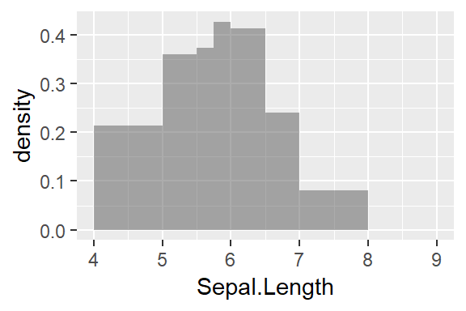

```r
gf_dhistogram( ~ Sepal.Length, data = iris, breaks = c(4,5,5.5,5.75,6,6.5,7,8,9))
```

It would be incorrect to choose `gf_histogram()()` since this distorts the picture of the data.

```r
gf_histogram( ~ Sepal.Length, data = iris, breaks = c(4,5,5.5,5.75,6,6.5,7,8,9))
```

[output not shown]

There are lots of arguments that control how these plots look. Here are just a few examples, some of which we have already seen.

show.legend = TRUE turns on a simple legend for the grouping variable.  
(There are ways to have more control, if you need it.) It is on by default in ggformula plots

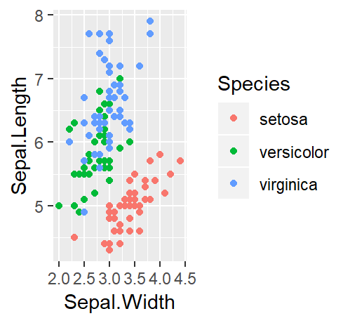

```r
gf_point(Sepal.Length ~ Sepal.Width, colour = ~Species, data = iris,
    show.legend = TRUE)
```

Sometimes it is nice to have elements of a plot be partly transparent. When such elements overlap, they get darker, showing us where data are “piling up.” Setting the alpha argument to a value between 0 and 1 controls the degree of transparency: 1 is completely opaque, 0 is invisible. The dotsize for `gf_dotplot()()` and size for `gf_point()()` arguments control “character expansion” and can be used to make the plotting “characters” larger or smaller by specifying the scaling ratio.

Here is another example using data on 150 iris plants of three species.

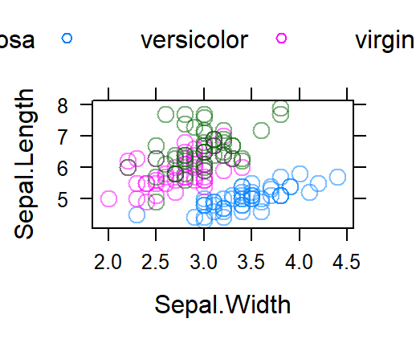

```r
xyplot(Sepal.Length ~ Sepal.Width, groups = Species, data = iris,
    auto.key = list(columns = 3),
    alpha = .5,
    cex = 1.3)
```

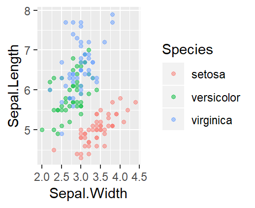

```r
gf_point(Sepal.Length ~ Sepal.Width, colour = ~Species, data = iris,
    show.legend = TRUE,
    alpha = .5,
    size = 1.3)
```

You can add a title or subtitle, or change the default labels of the axes in one of two ways. `gf_labs()()` allows the chaining syntax to be used.

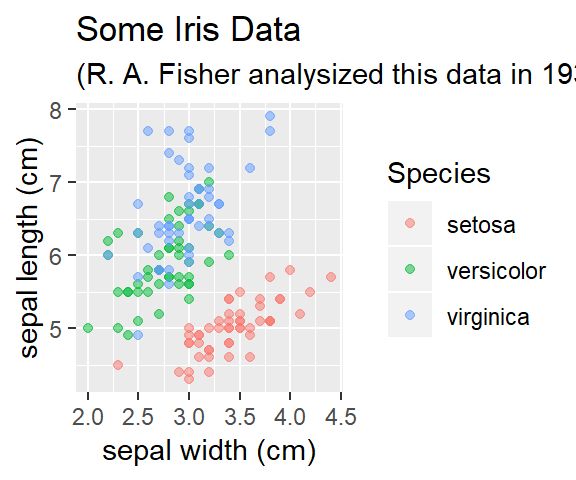

```r
gf_point(Sepal.Length ~ Sepal.Width, colour = ~Species, data = iris, alpha = .5)  %>% gf_labs(
  x = "sepal width (cm)",
  y = "sepal length (cm)",
  subtitle = "(R. A. Fisher analysized this data in 1936)",
  title = "Some Iris Data")
```

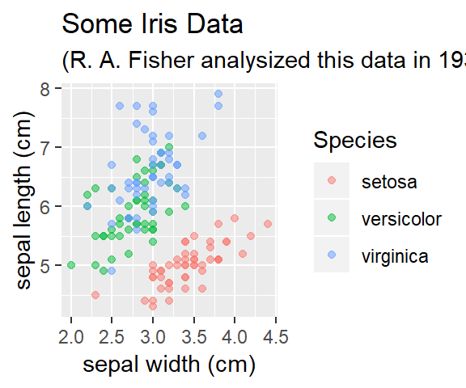

```r
gf_point(Sepal.Length ~ Sepal.Width, colour = ~Species, data = iris, alpha = .5,
         xlab = "sepal width (cm)",
         ylab = "sepal length (cm)",
         subtitle = "(R. A. Fisher analysized this data in 1936)",
         title = "Some Iris Data")
```

layout can be used to control the arrangement of panels in a multi-panel plot. The format is

```r
layout = c(cols, rows)
```

where `cols` is the number of columns and `rows` is the number of rows. (Columns first because that is the $x$-coordinate of the plot.)

These can be used to change the size of the data visual, set theme of the plot, change the color of the data visual and its shape.

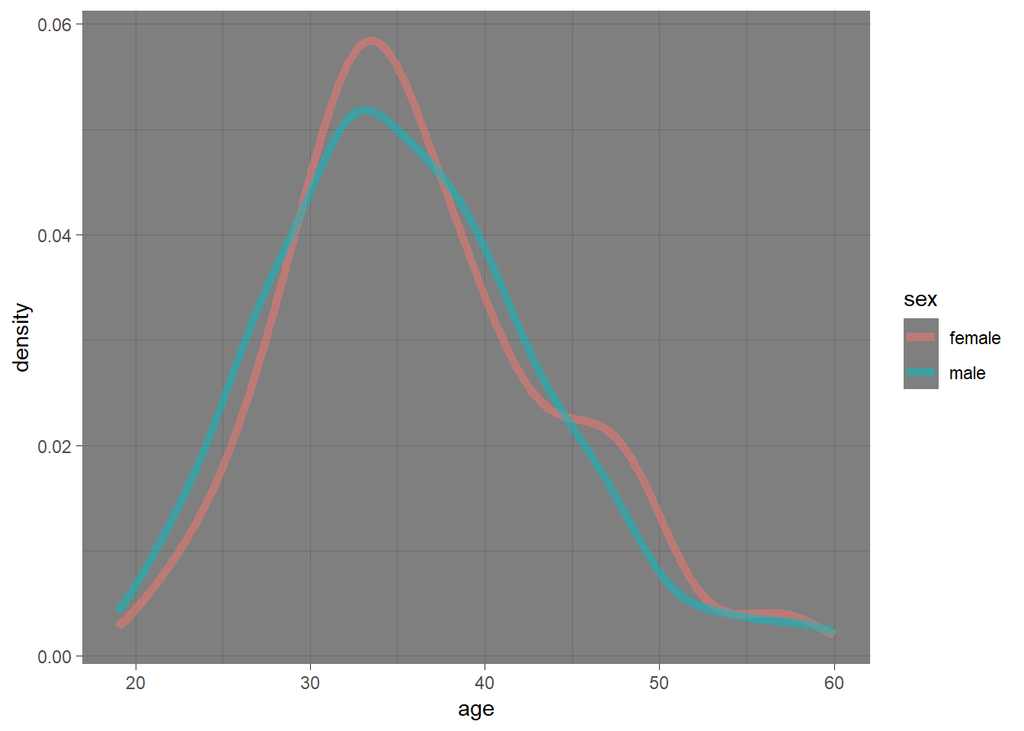

```r
gf_dens( ~age, data = HELPrct, colour = ~sex, size = 2) %>% gf_theme(theme = theme_dark())
```

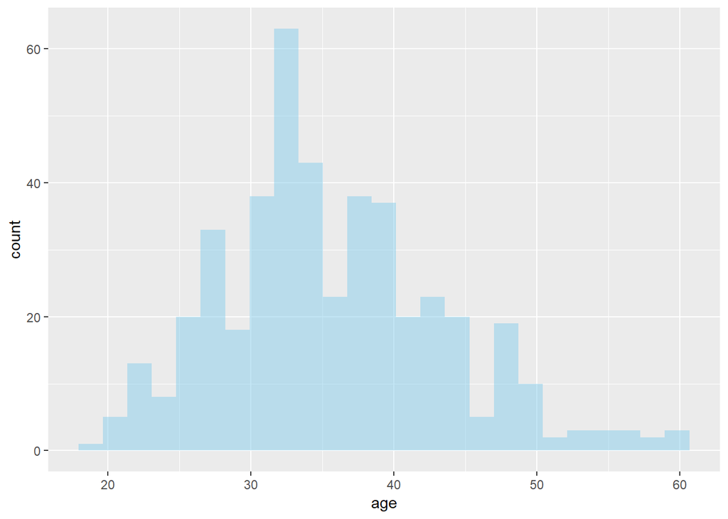

```r
gf_histogram( ~ age, data = HELPrct, fill = 'skyblue')
```

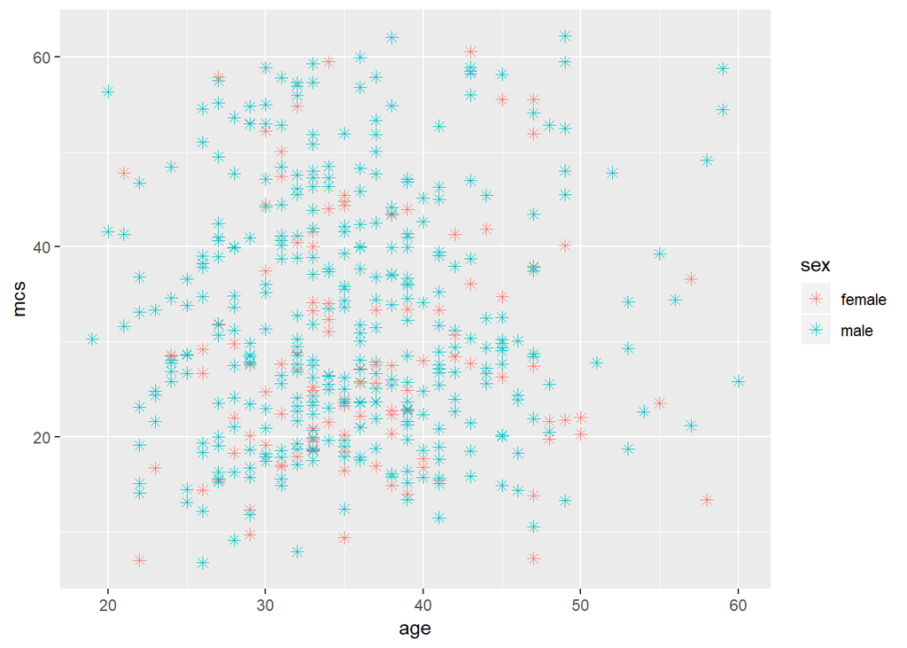

```r
# There are 25 numbered plot symbols; shape = plot character
gf_point( mcs ~ age, data = HELPrct, colour = ~sex,
        shape = 8, size = 2 )
```

You can a list of the hundreds of available color names using `colors()`

```r
colors()
```

Default settings for lattice graphics are set using `trellis.par.set()()`. Don’t like the default font sizes? You can change to a 7 point (base) font using

```r
trellis.par.set(fontsize = list(text = 7))    # base size for text is 7 point
```

Nearly every feature of a lattice plot can be controlled: fonts, colors, symbols, line thicknesses, colors, etc. Rather than describe them all here, we’ll mention only that groups of these settings can be collected into a theme.  
`show.settings()()` will show you what the theme looks like.

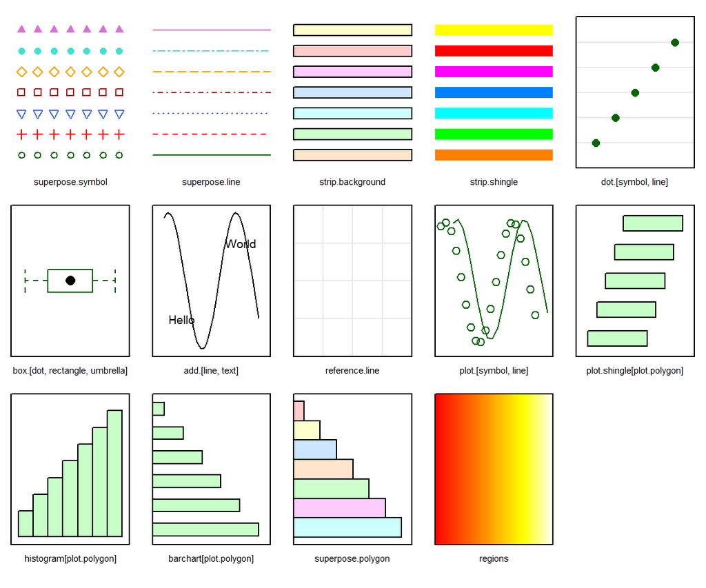

```r
trellis.par.set(theme = col.whitebg())      # a theme in the lattice package
show.settings()
```

```r
trellis.par.set(theme = col.mosaic())       # back to the mosaic theme
trellis.par.set(fontsize = list(text = 9))    # and back to a 9 point font
```

Want to save your settings?

```r
# save current settings
mySettings <- trellis.par.get()
# switch to mosaic defaults
trellis.par.set(theme = col.mosaic())
# switch back to my saved settings
trellis.par.set(mySettings)
```

You can save plots to files or copy them to the clipboard using the Export menu in the Plots tab. It is quite simple to copy the plots to the clipboard and then paste them into a Word document, for example. You can even adjust the height and width of the plot first to get it the shape you want.

R code and output can be copied and pasted as well. It’s best to use a fixed width font (like Courier) for R code so that things align properly.

RStudio also provides a way (actually multiple ways) to create documents that include text, R code, R output, and graphics all in one document so you don’t have to do any copying and pasting. This is a much better workflow since it avoids copy-and-paste which is error prone and makes it easy to regenerate an entire report should the data change (because you get more of it or correct an error, for example).

Use R s help system to find out what the i1 and i2 variables are in the HELPrct data frame. Make histograms for each variable and comment on what you find out. How would you describe the shape of these distributions? Do you see any outliers (observations that don’t seem to fit the pattern of the rest of the data)?

Compare the distributions of i1 and i2 among men and women.

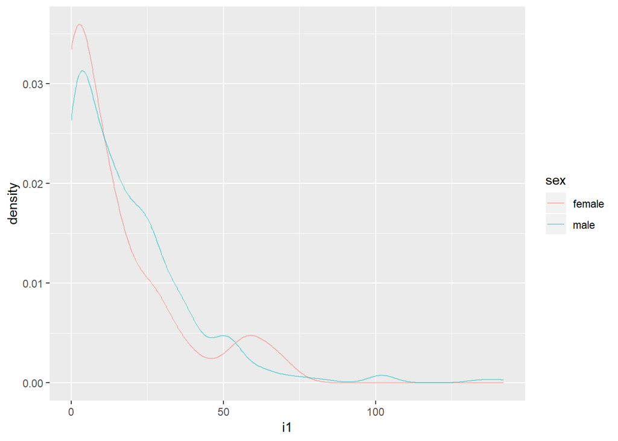

```r
gf_dens( ~i1, colour = ~sex, data = HELPrct )
```

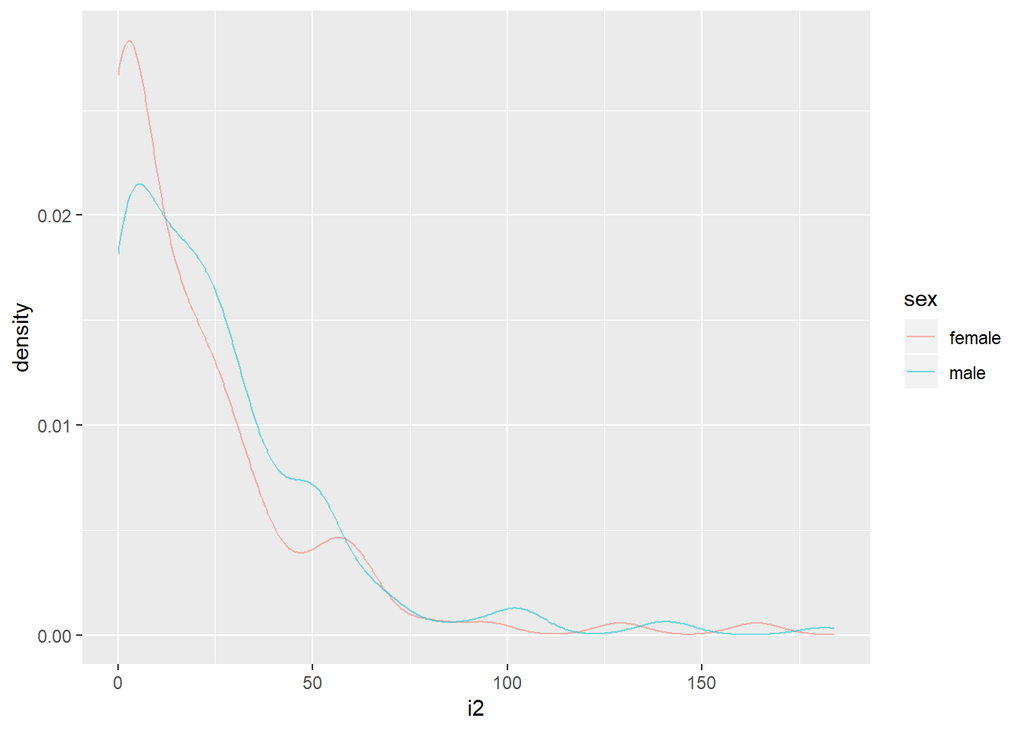

[output not shown]

```r
gf_dens( ~i2, colour = ~sex, data = HELPrct )
```

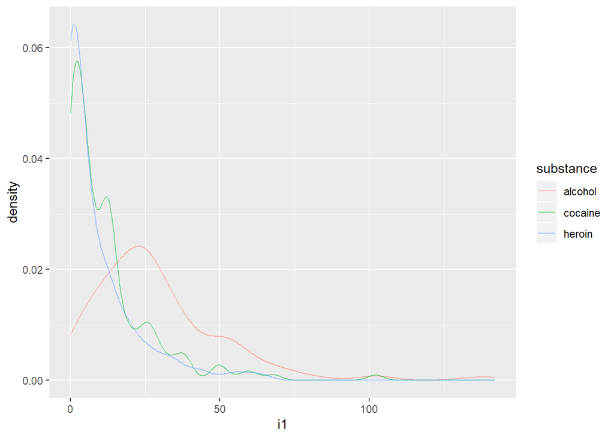

```r
gf_dens( ~i1, colour = ~substance, data = HELPrct )
```

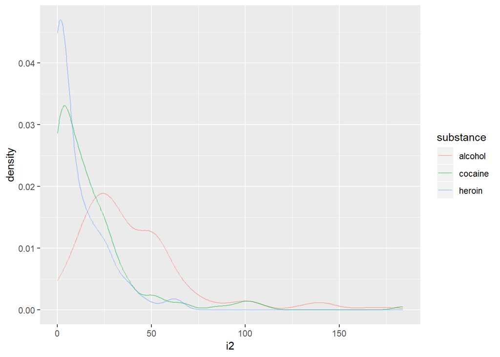

```r
gf_dens( ~i2, colour = ~substance, data = HELPrct )
```

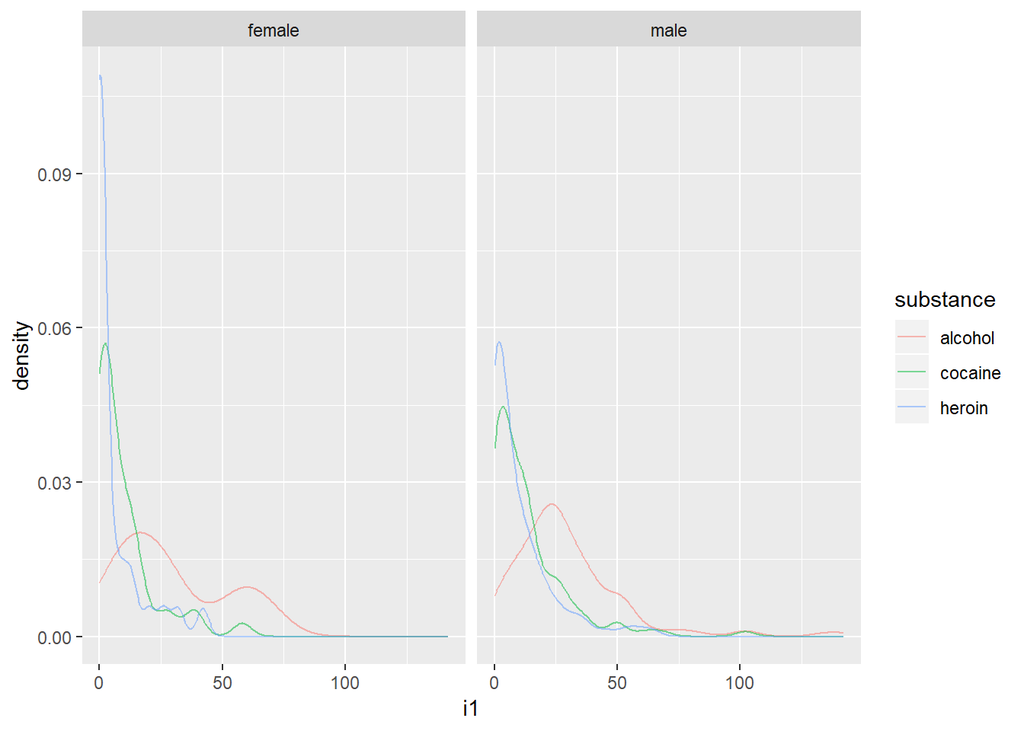

```r
gf_dens( ~i1|sex, colour = ~substance, data = HELPrct )
```

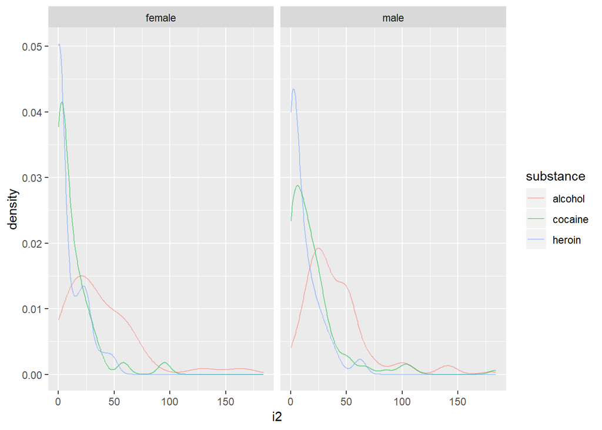

```r
gf_dens( ~i2|sex, colour = ~substance, data = HELPrct )
```

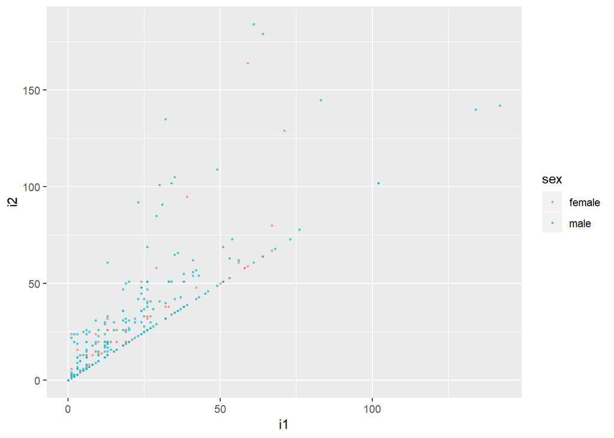

[output not shown]

[output not shown]

```r
gf_point( i2 ~ i1, colour = ~sex, data= HELPrct, alpha = .6, size = .6 )
```

The fusion2 data set in the **`fastR`** package contains genotypes for another SNP. Merge fusion1, fusion2, and pheno into a single data frame.

Note that fusion1 and fusion2 have the same columns.

```r
head(fusion1, 2)
```

```
##      id     marker markerID allele1 allele2 genotype Adose Cdose Gdose
## 1  9735 RS12255372        1       3       3       GG     0     0     2
## 2 10158 RS12255372        1       3       3       GG     0     0     2
##   Tdose
## 1     0
## 2     0
```

```r
head(fusion2, 2)
```

```
##      id    marker markerID allele1 allele2 genotype Adose Cdose Gdose
## 1  9735 RS7903146        2       2       2       CC     0     2     0
## 2 10158 RS7903146        2       2       2       CC     0     2     0
##   Tdose
## 1     0
## 2     0
```

You may want to use the suffixes argument to `merge()()` or rename the variables after you are done merging to make the resulting data frame easier to navigate.

Tidy up your data frame by dropping any columns that are redundant or that you just don’t want to have in your final data frame.

[^1]: For coloring a line or point, `colour()` is used